# Capstone Final Project, Summer 2026

Gender Differences or Schmifferences: Testing Replication with Open Source Data

Bradley Allen

# Abstract

# Intro

*Insanity is doing the same thing over and over again, but expecting different results*

– Rita Mae Brown (1983, p. 86)

To borrow from Rita Mae Brown, sanity is undercut when attempted replication yields different results over and over again. Indeed, failure to replicate psychological studies has led to a crisis of public trust in psychological science (Anvari & Lakens, 2018; Patil et al., 2016; Shrout & Rodgers, 2018). Some researchers have cited unpublished papers and publication bias as main contributors to the crisis, while others have cited poor experimental design, breadth of psychological subfields with varying research standards, and outsized media attention to replication failure (Bogdan, 2025; Johnson et al., 2016; Youyou et al., 2023). In recent years, methodological improvements have begun to repair the damage, yielding what has been deemed a “credibility revolution” (Korbmacher et al., 2023, p. 1). Despite the credibility revolution, there remains a strong need for replication targets (Pittelkow et al., 2023). Taken together, declaring a significant finding, then failing to replicate it reduces the credibility of scientific findings, and diminishes public trust, necessitating more studies of replication not only to repair the damage, but also to act as a sort of sanity check.

## Replication

Researchers Nosek and Errington (2020) suggested that researchers are remiss to replicate because it is seen as “a boring, uncreative, housekeeping activity” despite replication being a “vital contributor to research progress” (p. 1). They argued such a mindset stemmed from the strict definition of replication as algorithmically following the steps of another researcher. Such a definition, they observed, may be impossible because observational research, for example, cannot be replicated exactly (e.g., an earthquake or election that has occurred implies the novelty of the experience for those who observed it is impossible to replicate). Rather than restricting researchers to an exact step-by-step model, Nosek and Errington offered a new definition of replication: “[A] study for which any outcome would be considered diagnostic evidence about a claim from prior researchers” (p. 2). They concluded that this definition reduced emphasis on study characteristics and increased emphasis on interpreting outcomes. Critically, it would grant researchers the methodological breathing room to reduce perceptions of replication as a boring and uncreative activity.

In addition to redefining the issue, researchers have called for methodological change when conducting novel research. Shrout and Rodgers (2018) recommended following open science conventions such a pre-registration to prevent post-hoc revisions to research questions or p-hacking. They further recommended improvements to power analyses, deeper consideration of effect sizes (e.g., heterogeneity of results due to different sample sizes in the replication study), and increased disclosure of nonsignificant findings. Koole and Lakens (2012) suggested that publications link replication studies to the original papers, effectively creating co-citations as incentives. Broad consensus among research psychologists is that replication is necessary to validate existing findings, legitimize the field of study, and bolster public trust (Shrout & Rodgers, 2018; Youyou et al., 2023). Given the stakes, as Amir and Sharon (1990) put it, replication research is a must.

To assist research psychologists in replicating results, the Open-Source Psychometrics Project (2019) makes available large, open source data sets, often personality-centric, for use in publications. The present study will analyze the Answers to the Depression Anxiety Stress Scales data set available from the Open Psychometrics (2019) webpage. This data set contains more than 39 thousand responses to the Depression Anxiety Stress Scales (DASS) 42-item measure (P. F. Lovibond & Lovibond, 1995), Ten Item Personality Inventory (Gosling et al., 2003), and multiple demographic variables, such as race, gender, and orientation. Given the breadth of available variables, the use of validated psychological scales, the large sample size, and the duration of data collection (i.e., 3 years from 2017 to 2019), this data set is ideal for exploring the relationship between personality, depression, anxiety, stress, and demographic variables (e.g., gender).

## Gender Differences

When it comes to personality, stress, depression, anxiety, there are small to moderate differences between males and females. For example, females compared to males tend to report higher scores on personality traits agreeableness and lower scores in trait emotional stability (Lippa, 2010; Weisberg et al., 2011), where agreeableness is defined as a person’s tendency to seek social harmony and cooperation over competition or self-interest, while emotional stability is characterized by the ability to remain calm and resilient under pressure (Goldberg, 1990; McCrae & John, 1992). Emotional stability is often considered the strongest predictor of mental health indicators such as stress and anxiety for both males and females, though personality tends to better predict mental health indicators for males compared to females (Alizadeh et al., 2018; Uliaszek et al., 2010). Given these differences, the Answers to the Depression Anxiety Stress Scales data set is ideal for exploring gender differences in personality and mental health indicators (e.g., stress, depression, anxiety).

## Present Study

The goal of this project is to replicate findings of gender differences in personality, depression, anxiety, and stress. With respect to depression, anxiety, and stress, this study will include multi-group confirmatory factor analysis (CFA) of the DASS 42- and 21-item scales to replicate findings of measurement invariance across gender (i.e., females and males). Target CFA studies include Gomez et al. (2014) and Lu et al. (2018), both of which found the DASS 42- and 21-item measures performed equally across males and females. Target personality studies include Lippa (2010) and Weisberg et al. (2011), both of which found females reported higher scores on trait agreeableness and lower scores on trait emotional stability than males and that these differences tended to be small to moderate. Finally, this project will attempt to replicate findings by Alizadeh et al. (2018) and Uliaszek et al. (2010) who found emotional stability was the best predictor for depression, anxiety, and stress for both males and females, and that personality better predicted mental health for males compared to females. Given methodological variations (e.g., large sample, open source analytic software and packages), this project aims to answer how well open source data replicates findings of gender differences in personality and experiencing stress, anxiety, and depression.

This project will further contribute novel findings by applying machine learning models to differentially predict moderate to severe depression, anxiety, and stress in males and females using the behavioral and physiological subscales of the respective to the DASS-21 scale. This will be accomplished using clinical cut-off scores established by S.H. Lovibond and Lovibond (1995) to form a binary of normal (0) and moderate to severe (1) symptomatic expression.

# Method

## Participants

The raw data contained 39,775 observations. For participant responses to be considered, they were required to pass an attention check. The attention check consisted of a 16 word list (e.g., boat, paucity, lucid), 3 of which were fake (e.g., cuivocal, florted, verdid). Participants were instructed to check a box next to words whose definitions they knew for certain. Participants who checked boxes for all 3 words were excluded from analysis, resulting in a reduction of 326 participants. Additionally, the replication aspect of the study required that participants identified as male or female. As a result, 540 participants who selected “other” and 67 participants who did not provide a response were excluded. Finally, a total of 7 participants who listed their age as greater than 100 were removed. The remaining sample size was 38,835. Demographic results are reported in Table 1. Additional demographic analyses can be found in the Exploratory Data Analysis section.

#### Table 1

##### Demographic Characteristics by Gender

```r
# ====================================
# DEMOGRAPHICS TABLE
# ====================================

# 1. Generate counts, age statistics, and labels
summary_stats <- dass21 %>%
  group_by(gender) %>%
  summarise(
    n = n(),
    min_age  = min(age, na.rm = TRUE),
    max_age  = max(age, na.rm = TRUE),
    mean_age = sprintf("%.2f", round(mean(age, na.rm = TRUE), 2)),
    sd_age   = sprintf("%.2f", round(sd(age, na.rm = TRUE), 2)),
    .groups  = "drop"
  )

f_n <- summary_stats %>% filter(gender == "Female") %>% pull(n)
m_n <- summary_stats %>% filter(gender == "Male") %>% pull(n)

age_rows <- data.frame(
  Variable = c("Min", "Max", "M", "SD"),
  Female   = summary_stats %>%
    filter(gender == "Female") %>%
    select(min_age, max_age, mean_age, sd_age) %>%
    unlist() %>%
    as.character(),
  Male     = summary_stats %>%
    filter(gender == "Male") %>%
    select(min_age, max_age, mean_age, sd_age) %>%
    unlist() %>%
    as.character()
)

# 2. Process Categorical Profile Blocks with clean string mapping
demo_clean <- dass21 %>%
  select(gender, race, education, country) %>%
  mutate(
    country = fct_other(country, keep = c("US", "AU", "CA", "GB", "ID", "MY", "PH"), other_level = "Other"),
    country = case_match(
      country,
      "US" ~ "United States",
      "AU" ~ "Australia",
      "CA" ~ "Canada",
      "GB" ~ "Great Britain",
      "ID" ~ "Indonesia",
      "MY" ~ "Malaysia",
      "PH" ~ "Philippines",
      "Other" ~ "Other"),
    education = if_else(education == "University degree", "Undergraduate degree", education),
    across(everything(), as.character)
  ) %>%
  pivot_longer(cols = c(race, education, country), names_to = "group", values_to = "Variable") %>%
  filter(!is.na(Variable), Variable != "NA", Variable != "") %>%
  count(group, Variable, gender) %>%
  group_by(group, gender) %>%
  mutate(pct = round((n / sum(n)) * 100, 2)) %>%
  ungroup() %>%
  mutate(col_val = paste0(n, " (", sprintf("%.2f", pct), "%)")) %>%
  select(group, Variable, gender, col_val) %>%
  pivot_wider(names_from = gender, values_from = col_val, values_fill = "0 (0.00%)")

# 3. Setup explicit template order sequences
country_order   <- c("United States",
                     "Australia",
                     "Canada",
                     "Great Britain",
                     "Indonesia",
                     "Malaysia",
                     "Philippines",
                     "Other")
education_order <- c("Less than high school", "High school", "Undergraduate degree", "Graduate degree")
race_order      <- c("Arab", "Asian", "Black", "Indigenous Australian", "Native American", "White", "Other")

c_final   <- demo_clean %>% filter(group == "country") %>% slice(match(country_order, Variable))
e_block   <- demo_clean %>% filter(group == "education")
e_ordered <- e_block %>% filter(Variable %in% education_order) %>% slice(match(education_order, Variable))
e_other   <- e_block %>% filter(!Variable %in% education_order)
e_final   <- bind_rows(e_ordered, e_other)
r_final   <- demo_clean %>% filter(group == "race") %>% slice(match(race_order, Variable))

# 4. Programmatically compute row indices dynamically based on actual lengths
c_start <- 1
c_end   <- nrow(c_final)

e_start <- c_end + 1
e_end   <- c_end + nrow(e_final)

r_start <- e_end + 1
r_end   <- e_end + nrow(r_final)

a_start <- r_end + 1
a_end   <- r_end + nrow(age_rows)

final_table_data <- bind_rows(c_final, e_final, r_final) %>%
  select(Variable, Female, Male) %>%
  bind_rows(age_rows)

# 5. Set up dynamic top headers containing your centered group metrics
header_labels <- setNames(
  c(1, 1, 1),
  c("Variable and Group", paste0("Female (n = ", f_n, ")"), paste0("Male (n = ", m_n, ")"))
)

# 6. Render table with headers
final_table_data %>%
  kbl(
    col.names = c("", "n (%)", "n (%)"),
    # Align rows right for numbers, left for variable descriptions
    align = c("l", "r", "r"),
    booktabs = TRUE #,
    # caption = "Demographic Profile and Age Characteristics Split by Gender"
  ) %>%
  kable_styling(
    font_size = 16,
    html_font = "Times New Roman",
    bootstrap_options = c("striped", "hover"),
    latex_options = "striped",
    full_width = TRUE
  ) %>%
  column_spec(1, width = "50%") %>%
  column_spec(2:3, width = "25%") %>%
  add_header_above(header_labels) %>%
  # Overrides the second level subheaders to center perfectly under the top labels
  row_spec(0, align = "c") %>%
  pack_rows("Country", c_start, c_end, bold = TRUE) %>%
  pack_rows("Education", e_start, e_end, bold = TRUE) %>%
  pack_rows("Race", r_start, r_end, bold = TRUE) %>%
  pack_rows("Age (years)", a_start, a_end, bold = TRUE)
```

| Variable and Group | Female (n = 30156) n (%) | Male (n = 8679) n (%) |
| --- | --- | --- |
| **Country** |  |  |
| United States | 5375 (17.82%) | 2340 (26.96%) |
| Australia | 404 (1.34%) | 178 (2.05%) |
| Canada | 625 (2.07%) | 305 (3.51%) |
| Great Britain | 749 (2.48%) | 378 (4.36%) |
| Indonesia | 745 (2.47%) | 132 (1.52%) |
| Malaysia | 18085 (59.97%) | 3401 (39.19%) |
| Philippines | 590 (1.96%) | 142 (1.64%) |
| Other | 3582 (11.88%) | 1802 (20.77%) |
| **Education** |  |  |
| Less than high school | 2876 (9.66%) | 915 (10.68%) |
| High school | 11111 (37.33%) | 3576 (41.72%) |
| Undergraduate degree | 11942 (40.12%) | 2981 (34.78%) |
| Graduate degree | 3835 (12.88%) | 1099 (12.82%) |
| **Race** |  |  |
| Arab | 235 (0.78%) | 85 (0.98%) |
| Asian | 19032 (63.11%) | 3898 (44.91%) |
| Black | 406 (1.35%) | 168 (1.94%) |
| Indigenous Australian | 13 (0.04%) | 6 (0.07%) |
| Native American | 143 (0.47%) | 58 (0.67%) |
| White | 6688 (22.18%) | 3409 (39.28%) |
| Other | 3639 (12.07%) | 1055 (12.16%) |
| **Age (years)** |  |  |
| Min | 13 | 13 |
| Max | 85 | 89 |
| M | 22.99 | 25.05 |
| SD | 7.89 | 10.37 |

###### *Note.* *M* = Mean; *SD* = Standard Deviation.

## Materials

The Open Psychometrics (2019) data set Answers to the Depression Anxiety Stress Scales was explored. Observations included in the data were gathered through an online survey from 2017 to 2019, and recorded 39,775 responses. The raw data frame contained 172 variables, including 42 items for the Depression Anxiety Stress Scales (DASS) (P. F. Lovibond & Lovibond, 1995), 10 items from the Ten Item Personality Inventory (TIPI) (Gosling et al., 2003), 16 items for the attention check (i.e., one variable for each word), and a series of time related questions (e.g., how much time spent on each question, total survey completion time) and demographic variables (e.g., education level, college major, gender, religion, orientation).

## Procedure

Adjustments were made to the DASS-42 and TIPI scores. The DASS-42 responses were recorded on a scale from 1-4, but should have been 0-3. This was corrected by subtracting 1 from each participant’s response. The scores were then summed and stored as depression, anxiety, and stress scores, respectively (P. F. Lovibond & Lovibond, 1995). Additionally, scores for each DASS-42 subscale were calculated and stored (e.g., dysphoria, anhedonia, inertia). From the 42-item DASS, the same scores were similarly calculated and doubled for the DASS-21 subset (S. H. Lovibond & Lovibond, 1995). Responses to TIPI questions 2, 4, 6, 8, and 10 were reverse scored by subtracting each response from 8 (e.g., 8 - 1, 8 - 2, etc.) before taking the mean of each set and assigning them to their respective trait (Gosling et al., 2003).

Finally, user string data was extensively cleaned before exporting the data for analysis. User input of college majors were cleaned using the stringdist package (Loo, 2014), with the Jaro-Winkler algorithm enabled (Jaro, 1989; Winkler, 1990) to find the closes approximation of a specified major (e.g., user input of social psychology becomes psychology). The resulting standardized majors were grouped into 10 common categories (e.g., STEM and Natural Sciences, Health & Medicine). This data was only used for exploratory analysis due to the high likelihood of misclassification. To increase interpretability of the data, numeric values for gender, race, education level, and other variables were replaced with their respective strings (e.g., for race, 10 = Asian, 20 = Arab). Both the raw and cleaned data frames were used in the analysis, and filtered accordingly.

## Measures

### Depression, Anxiety, and Stress

#### Table 2

##### DASS-21 Descriptive Statistics by Gender

```r
# ====================================
# DASS DESCRIPTIVES BY GENDER
# ====================================

# 1. Map your raw subscale names to clean text
subscale_labels <- c(
  "depres21" = "Scale Total", "dysphoria" = "Dysphoria", "hopelessness" = "Hopelessness",
  "devaluation_of_life" = "Devaluation of Life", "self_depcrecation" = "Self-Deprecation",
  "lack_interest" = "Lack of Interest", "anhedonia" = "Anhedonia", "inertia" = "Inertia",
  "anxiet21" = "Scale Total", "autonomic_arousal" = "Autonomic Arousal",
  "skeletal_musculature_effects" = "Skeletal Musculature Effects",
  "situational_anxiety" = "Situational Anxiety", "anxious_affect" = "Anxious Affect",
  "stress21" = "Scale Total", "difficulty_relaxing" = "Difficulty Relaxing",
  "nervous_arousal" = "Nervous Arousal", "easily_upset" = "Easily Upset",
  "irritable" = "Irritable", "impatient" = "Impatient"
)

# 2. Process your raw data
dass_tab <- dass21 %>%
  select(gender, stress21, depres21, anxiet21, matches("^sub21")) %>%
  rename_with(~ str_replace(.x, "sub21_(.*)", "\\1"), starts_with("sub21_")) %>%
  rename(
    devaluation_of_life = deval_life,
    self_depcrecation = self_deprec,
    autonomic_arousal = auto_arousal,
    skeletal_musculature_effects = skeletal_muscle,
    situational_anxiety = sit_anxiety,
    difficulty_relaxing = diff_relaxing
  ) %>%
  group_by(gender) %>%
  summarise(across(
    everything(),
    list(
      mean = ~ mean(.x, na.rm = TRUE),
      sd   = ~ sd(.x, na.rm = TRUE),
      min  = ~ min(.x, na.rm = TRUE),
      max  = ~ max(.x, na.rm = TRUE),
      n    = ~ n()
    ),
    .names = "{.col}___{.fn}"
  )) %>%
  pivot_longer(
    cols = -gender,
    names_to = c("subscale", ".value"),
    names_pattern = "(.*)___(.*)"
  )

# 3. Extract n values dynamically
n_female <- dass_tab %>% filter(gender == "Female") %>% pull(n) %>% unique()
n_male   <- dass_tab %>% filter(gender == "Male") %>% pull(n) %>% unique()

# 4. Create the header vector safely to avoid the syntax error
header_labels <- setNames(
  c(1, 2, 2),
  c(" ", paste0("Female (n = ", n_female, ")"), paste0("Male (n = ", n_male, ")"))
)

# 5. Reshape side-by-side, drop n columns, and align rows
wide_table_data <- dass_tab %>%
  filter(subscale %in% names(subscale_labels)) %>%
  mutate(
    mean_fmt = sprintf("%.2f", round(mean, 2)),
    sd_fmt   = sprintf("%.2f", round(sd, 2))
  ) %>%
  select(subscale, gender, mean_fmt, sd_fmt) %>%
  pivot_wider(
    id_cols = subscale,
    names_from = gender,
    values_from = c(mean_fmt, sd_fmt),
    names_glue = "{gender}_{.value}"
  ) %>%
  slice(match(names(subscale_labels), subscale)) %>%
  mutate(Variable = subscale_labels) %>%
  select(
    Variable,
    Female_mean_fmt, Female_sd_fmt,
    Male_mean_fmt, Male_sd_fmt
  )

# 6. Generate the wide table layout
wide_table_data %>%
  kbl(
    col.names = c("Variable", "M", "SD", "M", "SD"),
    align = c("l", "r", "r", "r", "r"),
    booktabs = TRUE #,
    #caption = "Descriptive Statistics for DASS-21 Subscales Split by Gender"
  ) %>%
  kable_styling(
    font_size = 16,
    html_font = "Times New Roman",
    bootstrap_options = c("striped", "hover"),
    latex_options = "striped",
    full_width = TRUE
  ) %>%
  column_spec(1, width = "40%") %>%
  column_spec(2:5, width = "15%") %>%
  # Pass the safely constructed named vector here
  add_header_above(header_labels) %>%
  pack_rows("Depression", 1, 8, bold = TRUE) %>%
  pack_rows("Anxiety", 9, 13, bold = TRUE) %>%
  pack_rows("Stress", 14, 19, bold = TRUE) %>%
  row_spec(c(1, 9, 14), bold = TRUE)
```

| Variable | Female (n = 30156) M | Female (n = 30156) SD | Male (n = 8679) M | Male (n = 8679) SD |
| --- | --- | --- | --- | --- |
| **Depression** |  |  |  |  |
| Scale Total | 21.17 | 12.68 | 19.95 | 12.96 |
| Dysphoria | 3.63 | 2.13 | 3.28 | 2.19 |
| Hopelessness | 2.90 | 2.27 | 2.80 | 2.30 |
| Devaluation of Life | 2.70 | 2.33 | 2.60 | 2.34 |
| Self-Deprecation | 3.37 | 2.30 | 3.06 | 2.34 |
| Lack of Interest | 3.06 | 2.21 | 2.91 | 2.24 |
| Anhedonia | 2.46 | 2.07 | 2.36 | 2.08 |
| Inertia | 3.05 | 2.13 | 2.93 | 2.15 |
| **Anxiety** |  |  |  |  |
| Scale Total | 16.26 | 10.47 | 13.04 | 9.99 |
| Autonomic Arousal | 6.34 | 4.93 | 5.30 | 4.73 |
| Skeletal Musculature Effects | 1.93 | 2.08 | 1.47 | 1.94 |
| Situational Anxiety | 3.46 | 2.11 | 2.88 | 2.16 |
| Anxious Affect | 4.53 | 3.55 | 3.38 | 3.36 |
| **Stress** |  |  |  |  |
| Scale Total | 22.61 | 10.70 | 18.92 | 10.94 |
| Difficulty Relaxing | 2.99 | 2.09 | 2.80 | 2.14 |
| Nervous Arousal | 2.93 | 2.12 | 2.52 | 2.13 |
| Easily Upset | 7.18 | 3.73 | 5.61 | 3.83 |
| Irritable | 6.29 | 3.55 | 5.08 | 3.60 |
| Impatient | 3.23 | 2.15 | 2.91 | 2.17 |

###### *Note.* *M* = Mean; *SD* = Standard Deviation.

### Personality

Personality scores were calculated using the Ten Item Personality Inventory (TIPI) (Gosling et al., 2003). Participants responded to the prompt “I see myself as” and rated items such as “Extraverted, enthusiastic” and “Calm, emotionally stable.” Extraversion, agreeableness, conscientiousness, emotional stability, and openness to experience were all assessed using a 2-item scale, on a 7-point Likert scale (1 = *Disagree strongly*, 7 = *Agree strongly*). Descriptive statistics for each scale by gender are given in Table 4.

## Data Analysis

### Data Frames

After importing the raw and DASS-21 data frames, both were filtered to include only participants who passed the attention check, identified as either male or female, and whose age was less than or equal to 100. A third data frame was constructed to conduct CFA with the same filters, and one additional filter to extract the DASS questions (e.g., variables with a ‘Q’ prefix and ‘A’ suffix such as Q2A).

### Software Packages

This project was coded in R (R Core Team, 2026) using R Studio (Posit team, 2026) with the following packages: `broom` (Robinson et al., 2026), `effectsize` (Ben-Shachar et al., 2020), `kableExtra` (Zhu et al., 2024), `knitr` (Xie, 2025), `lavaan` (Rosseel, 2012), `naniar` (Tierney & Cook, 2023), `patchwork` (Pedersen, 2025), `purrr` (Wickham et al., 2026), `scales` (Wickham et al., 2025), `semTools` (Jorgensen et al., 2026), `tibble` (Müller et al., 2026), and `tidyverse` (Wickham et al., 2019).

### Missing Data

No patterns of missing data were found for mental health indicators (i.e., DASS), personality, or gender. Major category contained the higher percentage of missing data at about 35%, likely due to individuals who reported educational attainment not exceeding the high school level. The next highest percentage of missing data was in sexual orientation, amount to approximately 8%. There was less than 1.5% missing data in all other categories Fig. 1

#### Fig. 1

##### Missing Data

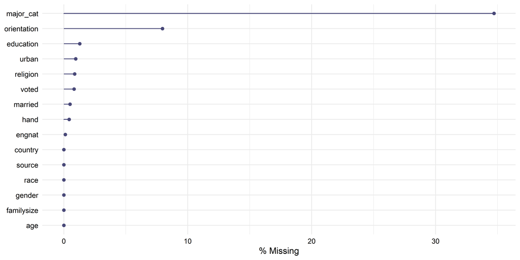

```r
# Missing demographic
missing_demo = gg_miss_var(dass21 %>%
           select(country, source, education, urban, gender, engnat, age,
                  hand, religion, orientation, race, voted, married,
                  familysize, major_cat),
           show_pct = TRUE) +
  theme(
    axis.title.y = element_blank(),
    axis.text.y = element_text(color = "black", size = 9),
    axis.text.x = element_text(color = "black"),
    legend.title = element_text(color = "black", size = 9),
    legend.text = element_text(color = "black", size = 9)
    )

missing_demo
```

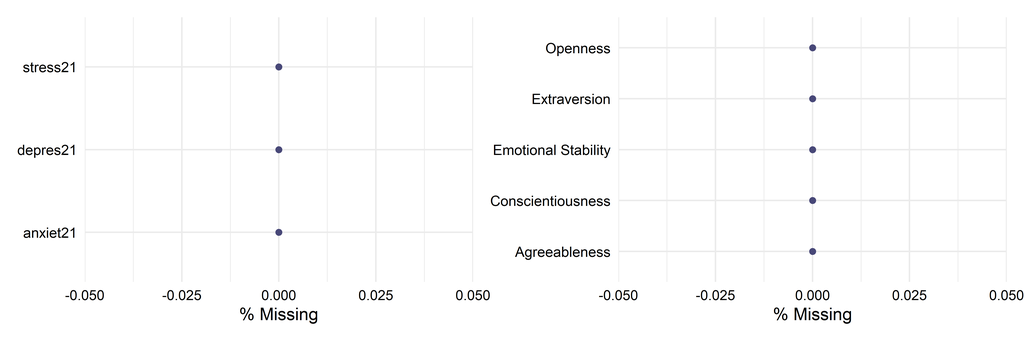

```r
# ====================================
# Missing DASS
# ====================================

missing_dass = gg_miss_var(dass21 %>%
           select(matches("sub42"), stress21, depres21, anxiet21),
           show_pct = TRUE) +
  theme(
    axis.title.y = element_blank(),
    axis.text.y = element_text(color = "black", size = 9),
    axis.text.x = element_text(color = "black"),
    legend.title = element_text(color = "black", size = 9),
    legend.text = element_text(color = "black", size = 9)
    )

# ====================================
# Missing Personality
# ====================================

missing_personality = gg_miss_var(dass21 %>%
           select(extraversion, agreeableness, conscientiousness, "emotional stability" = stability, openness) %>%
             rename_with(~ str_to_title(.)),
           show_pct = TRUE) +
  theme(
    axis.title.y = element_blank(),
    axis.text.y = element_text(color = "black", size = 9),
    axis.text.x = element_text(color = "black"),
    legend.title = element_text(color = "black", size = 9),
    legend.text = element_text(color = "black", size = 9)
        )

missing_traits = missing_dass + missing_personality
missing_traits
```

## Methodological Variations

There are several methodological variations between the present study and target studies. The primary difference is in the analytic tools. Researchers in the target studies used software such SPSS and Mplus to perform statistical analysis, while this study used R Studio and various software packages (e.g., `lavaan`). Secondly, given the breadth of this project, some analyses were partially replicated. For example, Weisberg et al. (2011) conducted independent samples t-tests on an expanded set of Big Five domains (e.g., enthusiasm, politeness), while this study only explored the core traits (i.e., openness, conscientiousness, extraversion, agreeableness, and neuroticism or emotional stability). Finally, this study employed multiple regression to explore the relationship between personality as a predictor of mental health indicators while Alizadeh et al. (2018) conducted Chi-square and multivariate analysis of variance to compare groups based on clinical cut-off scores.

# Results

## Confirmatory Factor Analysis (CFA)

Multi-group (CFA) was conducted on the 42- and 21-item Depression Anxiety Stress Scales (DASS) following Brown’s (2015) framework up to equal indicator error variances (i.e., strict measurement invariance) to ensure comparisons of group means were appropriate (Furr, 2018; Liu et al., 2017; Wu & Estabrook, 2016). CFA analyses were conducted in R Studio using the `lavaan` package (Rosseel, 2012), in accordance with syntax described in Hirschfeld and Brachel (2014) and Svetina et al. (2020). Six models were created: One model each for males and females, an equal form (configural) model (`group = gender`), an equal factor loadings (weak) model (`group.equal = loadings`), an equal intercepts (strong) model (`group.equal = loadings, thresholds`), and an equal indicator error variances (strict) model (`group.equal = loadings, thresholds, residuals`). Because the items utilize a 4-point Likert response scale, the data were treated as ordinal categories.

### CFA Models for DASS-42 and DASS-21 Item Scales

Models were estimated using the Weighted Least Squares Mean and Variance adjusted (WLSMV) estimator which provides robust standard errors and fit indices suited for non-continuous, non-normal data (Finney & DiStefano, 2006; Hirschfeld & Brachel, 2014; Rosseel, 2012). Model fit was evaluated using standard psychometric cutoffs: a Comparative Fit Index (CFI) and Tucker-Lewis Index (TLI) of $\geq .90$ for acceptable fit and $\geq .95$ for good fit, a Standardized Root Mean Square Residual (SRMR) $\leq .08$, and a Root Mean Square Error of Approximation (RMSEA) of $\leq .06$ for good fit and $\leq .08$ for acceptable fit (Bentler & Bonett, 1980; Hu & Bentler, 1999; MacCallum et al., 1996; Marsh et al., 2004). Full model results are reported in Table 3.

```r
# ====================================
# DASS-42 MODEL AND ORDERED ITEMS
# ====================================

dass42_model <- '
  Depression =~ Q3A + Q5A + Q10A + Q13A + Q16A + Q17A + Q21A + Q24A + Q26A + Q31A + Q34A + Q37A + Q38A + Q42A
  Anxiety =~ Q2A + Q4A + Q7A + Q9A + Q15A + Q19A + Q20A + Q23A + Q25A + Q28A + Q30A + Q36A + Q40A + Q41A
  Stress =~ Q1A + Q6A + Q8A + Q11A + Q12A + Q14A + Q18A + Q22A + Q27A + Q29A + Q32A + Q33A + Q35A + Q39A '

items_42 <- c("Q3A","Q5A","Q10A","Q13A","Q16A","Q17A","Q21A","Q24A","Q26A","Q31A","Q34A","Q37A","Q38A","Q42A",
              "Q2A","Q4A","Q7A","Q9A","Q15A","Q19A","Q20A","Q23A","Q25A","Q28A","Q30A","Q36A","Q40A","Q41A",
              "Q1A","Q6A","Q8A","Q11A","Q12A","Q14A","Q18A","Q22A","Q27A","Q29A","Q32A","Q33A","Q35A","Q39A")


# ====================================
# DASS-42 MULTI GROUP CFA
# ====================================

# Define the cache file path
cache_file <- "rds_files/dass42_models_cache.rds"

if (file.exists(cache_file)) {

  # 1. Load the cache file if it exists
  # message("Loading models from cache...")
  cached_models <- readRDS(cache_file)

  # 2. Extract the models back into separate variables
  fit42_male       <- cached_models$fit42_male
  fit42_female     <- cached_models$fit42_female
  fit42_equal      <- cached_models$fit42_equal

} else {

    # ====================================
    # STEP 1: CALC. CFA FOR MALES
    # ====================================

    # Fit the model separately per group using WLSMV and Theta parameterization
    fit42_male <- cfa(model = dass42_model,
                              data = cleaned_data %>% filter(gender == "Male"),
                              ordered = items_42,
                              estimator = "WLSMV",
                              parameterization = "theta"
                          )

    # View global fit statistics and parameter estimates
    # summary(fit42_sep_male, fit.measures = TRUE, standardized = TRUE, modindices = TRUE)


    # ====================================
    # STEP 2: CALC. CFA FOR FEMALES
    # ====================================

    fit42_female <- cfa(model = dass42_model,
                              data = cleaned_data %>% filter(gender == "Female"),
                              ordered = items_42,
                              meanstructure = TRUE,
                              estimator = "WLSMV",
                              parameterization = "theta")

    # Full model summary
    # summary(fit42_sep_female, fit.measures = TRUE, standardized = TRUE)


    # ====================================
    # STEP 3: CALC. CFA COMBINED (EQUAL FORM)
    # ====================================

    fit42_equal <- cfa(model = dass42_model,
                              data = cleaned_data,
                              ordered = items_42,
                              group = "gender",
                              meanstructure = TRUE,
                              estimator = "WLSMV",
                              parameterization = "theta")

    # Full model summary
    # summary(fit42_equal, fit.measures = TRUE, standardized = TRUE, modindices = TRUE)

    # Save all environment variables into a single named list
    models_to_cache <- list(
      fit42_male       = fit42_male,
      fit42_female     = fit42_female,
      fit42_equal      = fit42_equal
    )

    # Save RDS Object
    saveRDS(models_to_cache, file = cache_file)
    # message("Models successfully computed and cached!")
}

# ====================================
# DASS-42 RESULTS TABLE
# ====================================

# Define the cache file path
cache_file <- "rds_files/fit42_table.rds"

if (file.exists(cache_file)) {
  # 1. Load the cache list if it exists
  cached_data <- readRDS(cache_file)

  # 2. Extract everything back into the environment
  fit42_male   <- cached_data$fit42_male
  fit42_female <- cached_data$fit42_female
  fit42_equal  <- cached_data$fit42_equal
  fit42_table  <- cached_data$fit42_table

} else {
  # 1. Define the specific fit indices you need
  selected_indices = c(
    "chisq.scaled", "df.scaled", "rmsea.robust",
    "rmsea.ci.lower.robust", "rmsea.ci.upper.robust",
    "rmsea.pvalue.robust", "srmr", "cfi.robust", "tli.robust"
  )

  # 2. Create a named list of your fitted models
  model_list42 = list(
    "M1: Single-group (Males)"   = fit42_male,
    "M2: Single-group (Females)" = fit42_female,
    "M3: Equal form"             = fit42_equal
  )

  # 3. Extract, combine, and format the data
  fit42_table = model_list42 %>%
    lapply(function(m) fitmeasures(m, selected_indices)) %>%
    do.call(rbind, .) %>%
    as.data.frame() %>%
    tibble::rownames_to_column(var = "Model") %>%
    mutate(across(where(is.numeric), ~ round(., 3))) %>%
    rename(
      `Chi-Sq (Scaled)` = chisq.scaled,
      `df (Scaled)`     = df.scaled,
      `RMSEA (Robust)`  = rmsea.robust,
      `RMSEA CI LL`     = rmsea.ci.lower.robust,
      `RMSEA CI UL`     = rmsea.ci.upper.robust,
      `RMSEA p-value`   = rmsea.pvalue.robust,
      `SRMR`            = srmr,
      `CFI (Robust)`    = cfi.robust,
      `TLI (Robust)`    = tli.robust
    )

  # 4. Save models AND the table into a single named list
  data_to_cache <- list(
    fit42_male   = fit42_male,
    fit42_female = fit42_female,
    fit42_equal  = fit42_equal,
    fit42_table  = fit42_table
  )

  # Save the combined RDS Object
  saveRDS(data_to_cache, file = cache_file)
}

# 5. View your final table
# print(fit42_table)

# print(modificationIndices(fit42_equal, sort = TRUE, maximum.number = 10))

# ====================================
# DASS-42 MULTI GROUP CFA ADJUSTED
# ====================================

dass42_adjusted_model <- '
  Depression =~ Q3A + Q5A + Q10A + Q13A + Q16A + Q17A + Q21A + Q24A + Q26A + Q31A + Q34A + Q37A + Q38A + Q42A
  Anxiety =~ Q2A + Q4A + Q7A + Q9A + Q15A + Q19A + Q20A + Q23A + Q25A + Q28A + Q30A + Q36A + Q40A + Q41A
  Stress =~ Q1A + Q6A + Q8A + Q11A + Q12A + Q14A + Q18A + Q22A + Q27A + Q29A + Q32A + Q33A + Q35A + Q39A
  Q7A ~~ Q41A
  Q21A ~~ Q38A
  Q17A ~~ Q34A
  Q10A ~~ Q37A
  Q32A ~~ Q35A '

# Define the cache file path
cache_file <- "rds_files/dass42_adjusted_models_cache.rds"

if (file.exists(cache_file)) {

  # 1. Load the cache file if it exists
  # message("Loading models from cache...")
  cached_models <- readRDS(cache_file)

  # 2. Extract the models back into separate variables
  fit42adj_male       <- cached_models$fit42adj_male
  fit42adj_female     <- cached_models$fit42adj_female
  fit42adj_equal      <- cached_models$fit42adj_equal
  fit42adj_loadings   <- cached_models$fit42adj_loadings
  fit42adj_intercepts <- cached_models$fit42adj_intercepts
  fit42adj_residuals  <- cached_models$fit42adj_residuals

} else {

    # ====================================
    # STEP 1: CALC. CFA FOR MALES
    # ====================================

    # Fit the model separately per group using WLSMV and Theta parameterization
    fit42adj_male <- cfa(model = dass42_adjusted_model,
                              data = cleaned_data %>% filter(gender == "Male"),
                              ordered = items_42,
                              estimator = "WLSMV",
                              parameterization = "theta"
                          )

    # View global fit statistics and parameter estimates
    # summary(fit42adj_sep_male, fit.measures = TRUE, standardized = TRUE, modindices = TRUE)


    # ====================================
    # STEP 2: CALC. CFA FOR FEMALES
    # ====================================

    fit42adj_female <- cfa(model = dass42_adjusted_model,
                              data = cleaned_data %>% filter(gender == "Female"),
                              ordered = items_42,
                              meanstructure = TRUE,
                              estimator = "WLSMV",
                              parameterization = "theta")

    # Full model summary
    # summary(fit42adj_sep_female, fit.measures = TRUE, standardized = TRUE)


    # ====================================
    # STEP 3: CALC. CFA COMBINED (EQUAL FORM)
    # ====================================

    fit42adj_equal <- cfa(model = dass42_adjusted_model,
                              data = cleaned_data,
                              ordered = items_42,
                              group = "gender",
                              meanstructure = TRUE,
                              estimator = "WLSMV",
                              parameterization = "theta")

    # Full model summary
    # summary(fit42adj_equal, fit.measures = TRUE, standardized = TRUE, modindices = TRUE)


    # ====================================
    # STEP 4: EQUAL FACTOR LOADINGS
    # ====================================

    fit42adj_loadings <- cfa(model = dass42_adjusted_model,
                              data = cleaned_data,
                              ordered = items_42,
                              group = "gender",
                              group.equal = "loadings",
                              estimator = "WLSMV",
                              parameterization = "theta")

    # # summary(fit42adj_loadings, fit.measures = TRUE, standardized = TRUE, modindices = TRUE)

    # ====================================
    # STEP 5: EQUAL INDICATOR INTERCEPTS
    # ====================================

    fit42adj_intercepts <- cfa(model = dass42_adjusted_model,
                              data = cleaned_data,
                              ordered = items_42,
                              group = "gender",
                              meanstructure = TRUE,
                              group.equal = c("loadings", "thresholds"),
                              estimator = "WLSMV",
                              parameterization = "theta"
                          )
    # summary(fit42adj_intercepts, fit.measures = TRUE, standardized = TRUE, modindices = TRUE)

    # ====================================
    # STEP 6: EQUAL INDICATOR ERROR VARIANCES
    # ====================================

    fit42adj_residuals <- cfa(model = dass42_adjusted_model,
                              data = cleaned_data,
                              ordered = items_42,
                              group = "gender",
                              meanstructure = TRUE,
                              group.equal = c("loadings", "thresholds", "residuals"),
                              estimator = "WLSMV",
                              parameterization = "theta")

    # summary(fit42adj_residuals, fit.measures = TRUE, standardized = TRUE, modindices = TRUE)

    # Save all environment variables into a single named list
    models_to_cache <- list(
      fit42adj_male       = fit42adj_male,
      fit42adj_female     = fit42adj_female,
      fit42adj_equal      = fit42adj_equal,
      fit42adj_loadings   = fit42adj_loadings,
      fit42adj_intercepts = fit42adj_intercepts,
      fit42adj_residuals  = fit42adj_residuals
    )

    # Save RDS Object
    saveRDS(models_to_cache, file = cache_file)
    # message("Models successfully computed and cached!")
}
```

The initial baseline CFA for the DASS-42 revealed structural strain $(\text{CFI}_{\text{robust}} = .881, \text{TLI}_{\text{robust}} = .875)$. Examination of the modification indices indicated substantial unmodeled residual covariance between similar items within the same subscales (e.g., trembling items Q7A and Q41A; meaningless/empty life items Q21A and Q38A). After specifying five local residual error covariances to absorb this method effects variance, the adjusted DASS-42 model achieved acceptable fit $(\text{CFI}_{\text{robust}} = .910, \text{TLI}_{\text{robust}} = .905, \text{RMSEA}_{\text{robust}} = .063, \text{SRMR} = .039)$.

```r
# ====================================
# DASS-21 MODEL AND ORDERED ITEMS
# ====================================

dass21_model <- '
  Depression =~ Q3A + Q5A + Q10A + Q13A + Q16A + Q17A + Q21A
  Anxiety =~ Q2A + Q4A + Q7A + Q9A + Q15A + Q19A + Q20A
  Stress =~ Q1A + Q6A + Q8A + Q11A + Q12A + Q14A + Q18A
'

items_21 <- c("Q3A","Q5A","Q10A","Q13A","Q16A","Q17A","Q21A",
              "Q2A","Q4A","Q7A","Q9A","Q15A","Q19A","Q20A",
              "Q1A","Q6A","Q8A","Q11A","Q12A","Q14A","Q18A")

# ====================================
# DASS-21 MULTI GROUP CFA
# ====================================

# Define the cache file path
cache_file <- "rds_files/dass21_models_cache.rds"

if (file.exists(cache_file)) {

  # 1. Load the cache file if it exists
  # message("Loading models from cache...")
  cached_models <- readRDS(cache_file)

  # 2. Extract the models back into separate variables
  fit21_male       <- cached_models$fit21_male
  fit21_female     <- cached_models$fit21_female
  fit21_equal      <- cached_models$fit21_equal
  fit21_loadings   <- cached_models$fit21_loadings
  fit21_intercepts <- cached_models$fit21_intercepts
  fit21_residuals  <- cached_models$fit21_residuals

} else {

    # ====================================
    # STEP 1: CALC. CFA FOR MALES
    # ====================================

    # Fit the model separately per group using WLSMV and Theta parameterization
    fit21_male <- cfa(model = dass21_model,
                              data = cleaned_data %>% filter(gender == "Male"),
                              ordered = items_21,
                              estimator = "WLSMV",
                              parameterization = "theta"
                          )

    # View global fit statistics and parameter estimates
    # summary(fit21_sep_male, fit.measures = TRUE, standardized = TRUE, modindices = TRUE)


    # ====================================
    # STEP 2: CALC. CFA FOR FEMALES
    # ====================================

    fit21_female <- cfa(model = dass21_model,
                              data = cleaned_data %>% filter(gender == "Female"),
                              ordered = items_21,
                              meanstructure = TRUE,
                              estimator = "WLSMV",
                              parameterization = "theta")

    # Full model summary
    # summary(fit21_sep_female, fit.measures = TRUE, standardized = TRUE)


    # ====================================
    # STEP 3: CALC. CFA COMBINED (EQUAL FORM)
    # ====================================

    fit21_equal <- cfa(model = dass21_model,
                              data = cleaned_data,
                              ordered = items_21,
                              group = "gender",
                              meanstructure = TRUE,
                              estimator = "WLSMV",
                              parameterization = "theta")

    # Full model summary
    # summary(fit21_equal, fit.measures = TRUE, standardized = TRUE, modindices = TRUE)


    # ====================================
    # STEP 4: EQUAL FACTOR LOADINGS
    # ====================================

    fit21_loadings <- cfa(model = dass21_model,
                              data = cleaned_data,
                              ordered = items_21,
                              group = "gender",
                              group.equal = "loadings",
                              estimator = "WLSMV",
                              parameterization = "theta")

    # # summary(fit21_loadings, fit.measures = TRUE, standardized = TRUE, modindices = TRUE)

    # ====================================
    # STEP 5: EQUAL INDICATOR INTERCEPTS
    # ====================================

    fit21_intercepts <- cfa(model = dass21_model,
                              data = cleaned_data,
                              ordered = items_21,
                              group = "gender",
                              meanstructure = TRUE,
                              group.equal = c("loadings", "thresholds"),
                              estimator = "WLSMV",
                              parameterization = "theta"
                          )
    # summary(fit21_intercepts, fit.measures = TRUE, standardized = TRUE, modindices = TRUE)

    # ====================================
    # STEP 6: EQUAL INDICATOR ERROR VARIANCES
    # ====================================

    fit21_residuals <- cfa(model = dass21_model,
                              data = cleaned_data,
                              ordered = items_21,
                              group = "gender",
                              meanstructure = TRUE,
                              group.equal = c("loadings", "thresholds", "residuals"),
                              estimator = "WLSMV",
                              parameterization = "theta")

    # summary(fit21_residuals, fit.measures = TRUE, standardized = TRUE, modindices = TRUE)

    # Save all environment variables into a single named list
    models_to_cache <- list(
      fit21_male       = fit21_male,
      fit21_female     = fit21_female,
      fit21_equal      = fit21_equal,
      fit21_loadings   = fit21_loadings,
      fit21_intercepts = fit21_intercepts,
      fit21_residuals  = fit21_residuals
    )

    # Save RDS Object
    saveRDS(models_to_cache, file = cache_file)
    # message("Models successfully computed and cached!")
}
```

Conversely, the DASS-21 baseline model achieved similar results without any post-hoc modifications $(\text{CFI}_{\text{robust}} = .932, \text{TLI}_{\text{robust}} = .923, \text{RMSEA}_{\text{robust}} = .073, \text{SRMR} = .038)$. Furthermore, based on cut-off scores established by Nunnally (1994), the subscales demonstrated good $(\alpha \geq .80)$ model-based internal consistency using McDonald’s omega (McDonald, 1999), yielding coefficients of $\omega = .92$ for Depression, $\omega = .84$ for Anxiety, and $\omega = .87$ for Stress. This approach was preferred over Cronbach’s alpha because coefficient omega provides a more accurate estimate of internal consistency when handling categorical data and when the assumption of tau-equivalence is violated (Hayes & Coutts, 2020; McNeish, 2018).

Due to the large sample size ($N = 38,835$), the Satorra-Bentler scaled chi-square difference test ($\Delta\chi^2$) is highly oversensitive to trivial group variations and expectedly yielded statistically significant results. Therefore, invariance was determined by tracking changes in the comparative fit index ($\Delta\text{CFI}$), where a value $\leq .010$ indicates that invariance holds (Chen, 2007; Cheung & Rensvold, 2002). For the DASS-21, configural invariance was established ($\text{CFI}_{\text{robust}} = .932$, $\text{RMSEA}_{\text{robust}} = .073$). The highly constrained equal indicator error variances (strict) model fit the data equally well ($\text{CFI}_{\text{robust}} = .932$, $\text{RMSEA}_{\text{robust}} = .071$). The resulting change in fit was negligible ($\Delta\text{CFI} = 0$, $\Delta\text{RMSEA} = -.002$), confirming full scalar invariance across genders. For the adjusted DASS-42, the equal form (configural) model ($\text{CFI}_{\text{robust}} = .910$, $\text{RMSEA}_{\text{robust}} = .063$) was statistically compared against the constrained equal indicator error variances (strict) model ($\text{CFI}_{\text{robust}} = .910$, $\text{RMSEA}_{\text{robust}} = .062$). Mirroring the short-form findings, the fit shift was effectively zero ($\Delta\text{CFI} = 0$, $\Delta\text{RMSEA} = -.001$), establishing full scalar invariance for the 42-item scale. Collectively, these invariance findings verify that item mechanics, factor structures, and category thresholds mean the same thing to both men and women, validating subsequent comparisons of latent factor means or observed manifest sum scores.

Because the DASS-21 performed equally to the DASS-42, subsequent analyses will be conducted using the shorter DASS-21 scale to compare observed means on depression, anxiety, and stress.

#### Table 3

##### Comparison of Model Fit Indices for DASS-42 Adjusted and DASS-21 Models

```r
# ====================================
# DASS-42 ADJUSTED TABLE DATA
# ====================================

# Define the RDS file path
rds_path <- "rds_files/fit42adj_table.rds"

# Check if the RDS file already exists
if (file.exists(rds_path)) {

  # Load the existing table from the file
  fit42adj_table <- readRDS(rds_path)
  # message("Loaded existing table from RDS file.")

} else {

  # 1. Define the specific fit indices you need
  selected_indices <- c(
    "chisq.scaled", "df.scaled", "rmsea.robust",
    "rmsea.ci.lower.robust", "rmsea.ci.upper.robust",
    "rmsea.pvalue.robust", "srmr", "cfi.robust", "tli.robust"
  )

  # 2. Create a named list of your fitted models
  model_list42adj <- list(
    "M1: Single-group (Males)"              = fit42adj_male,
    "M2: Single-group (Females)"            = fit42adj_female,
    "M3: Equal form"                        = fit42adj_equal,
    "M4: Equal factor loadings"             = fit42adj_loadings,
    "M5: Equal Intercepts"                  = fit42adj_intercepts,
    "M6: Equal indicator error variances"   = fit42adj_residuals
  )

  # 3. Extract, combine, and format the data
  fit42adj_table <- model_list42adj %>%
    # Extract fit measures for each model in the list
    lapply(function(m) fitmeasures(m, selected_indices)) %>%
    # Bind the vector results into rows of a data frame
    do.call(rbind, .) %>%
    # Convert to a standard data frame
    as.data.frame() %>%
    # Move the model names from row names to an actual column
    tibble::rownames_to_column(var = "Model") %>%
    # Optional: Round all numeric metrics to 3 decimal places for readability
    mutate(across(where(is.numeric), ~ round(., 3))) %>%
    mutate(chisq.scaled = round(chisq.scaled, 1)) %>%
    rename(
      `Chi-Sq (Scaled)` = chisq.scaled,
      `df (Scaled)`     = df.scaled,
      `RMSEA (Robust)`  = rmsea.robust,
      `RMSEA CI LL`     = rmsea.ci.lower.robust,
      `RMSEA CI UL`     = rmsea.ci.upper.robust,
      `RMSEA p-value`   = rmsea.pvalue.robust,
      `SRMR`            = srmr,
      `CFI (Robust)`    = cfi.robust,
      `TLI (Robust)`    = tli.robust
    )

  # Save the newly created table to the RDS file
  saveRDS(fit42adj_table, file = rds_path)
  # message("Generated new table and saved to RDS file.")
}

# ====================================
# DASS-21 TABLE DATA
# ====================================

# Define the RDS directory path
rds_path_21 <- "rds_files/fit21_table.rds"

# Check if the RDS file already exists
if (file.exists(rds_path_21)) {

  # Load the existing table from the file
  fit21_table <- readRDS(rds_path_21)
  # message("Loaded existing fit21 table from RDS file.")

} else {

  # 1. Define the specific fit indices you need
  selected_indices <- c(
    "chisq.scaled", "df.scaled", "rmsea.robust",
    "rmsea.ci.lower.robust", "rmsea.ci.upper.robust",
    "rmsea.pvalue.robust", "srmr", "cfi.robust", "tli.robust"
  )

  # 2. Create a named list of your fitted models
  model_list21 <- list(
    "M1: Single-group (Males)"            = fit21_male,
    "M2: Single-group (Females)"          = fit21_female,
    "M3: Equal form"                      = fit21_equal,
    "M4: Equal factor loadings"           = fit21_loadings,
    "M5: Equal Intercepts"                = fit21_intercepts,
    "M6: Equal indicator error variances" = fit21_residuals
  )

  # 3. Extract, combine, and format the data
  fit21_table <- model_list21 %>%
    # Extract fit measures for each model in the list
    lapply(function(m) fitmeasures(m, selected_indices)) %>%
    # Bind the vector results into rows of a data frame
    do.call(rbind, .) %>%
    # Convert to a standard data frame
    as.data.frame() %>%
    # Move the model names from row names to an actual column
    tibble::rownames_to_column(var = "Model") %>%
    # Round all numeric metrics to 3 decimal places
    mutate(across(where(is.numeric), ~ round(., 3))) %>%
    # Overwrite the chi-square column specifically to 1 decimal place
    mutate(chisq.scaled = round(chisq.scaled, 1)) %>%
    rename(
      `Chi-Sq (Scaled)` = chisq.scaled,
      `df (Scaled)`     = df.scaled,
      `RMSEA (Robust)`  = rmsea.robust,
      `RMSEA CI LL`     = rmsea.ci.lower.robust,
      `RMSEA CI UL`     = rmsea.ci.upper.robust,
      `RMSEA p-value`   = rmsea.pvalue.robust,
      `SRMR`            = srmr,
      `CFI (Robust)`    = cfi.robust,
      `TLI (Robust)`    = tli.robust
    )

  # 4. FIXED: Save the variable AFTER the pipe finishes executing
  saveRDS(fit21_table, file = rds_path_21)
  # message("Generated new fit21 table and saved to RDS file.")
}

# ====================================
# DASS-42, 21 CFA RESULTS TABLE
# ====================================

# Combine the data
combined_models <- rbind(fit42adj_table, fit21_table) %>%
  select(Model, everything()) %>%
  select(-`RMSEA p-value`)

# Generate the structured model fit table
combined_models %>%
  kbl(
    align = c("l", "r", "r", "r", "r", "r", "r", "r", "r"),
    booktabs = TRUE #,
    # caption = "Comparison of Model Fit Indices for DASS-42 Adjusted and DASS-21 Models"
  ) %>%
  kable_classic(full_width = FALSE, html_font = "Times New Roman") %>%
  kable_styling(
    font_size = 16,
    latex_options = "striped",
    bootstrap_options = "striped"
  ) %>%
  pack_rows("DASS-42 ADJUSTED MODELS", 1, 6, bold = TRUE) %>%
  pack_rows("DASS-21 MODELS", 7, 12, bold = TRUE)
```

| Model | Chi-Sq (Scaled) | df (Scaled) | RMSEA (Robust) | RMSEA CI LL | RMSEA CI UL | SRMR | CFI (Robust) | TLI (Robust) |
| --- | --- | --- | --- | --- | --- | --- | --- | --- |
| **DASS-42 ADJUSTED MODELS** |  |  |  |  |  |  |  |  |
| M1: Single-group (Males) | 23427.9 | 811 | 0.064 | 0.063 | 0.065 | 0.039 | 0.908 | 0.903 |
| M2: Single-group (Females) | 90173.9 | 811 | 0.062 | 0.062 | 0.063 | 0.039 | 0.911 | 0.905 |
| M3: Equal form | 110540.0 | 1622 | 0.063 | 0.062 | 0.063 | 0.039 | 0.910 | 0.905 |
| M4: Equal factor loadings | 67809.4 | 1661 | 0.062 | 0.062 | 0.062 | 0.040 | 0.910 | 0.907 |
| M5: Equal Intercepts | 110147.4 | 1703 | 0.063 | 0.062 | 0.063 | 0.039 | 0.910 | 0.909 |
| M6: Equal indicator error variances | 69002.8 | 1745 | 0.062 | 0.062 | 0.062 | 0.040 | 0.910 | 0.911 |
| **DASS-21 MODELS** |  |  |  |  |  |  |  |  |
| M1: Single-group (Males) | 6718.2 | 186 | 0.072 | 0.070 | 0.073 | 0.039 | 0.935 | 0.926 |
| M2: Single-group (Females) | 24891.1 | 186 | 0.073 | 0.072 | 0.074 | 0.038 | 0.931 | 0.922 |
| M3: Equal form | 31119.7 | 372 | 0.073 | 0.072 | 0.073 | 0.038 | 0.932 | 0.923 |
| M4: Equal factor loadings | 20987.1 | 390 | 0.071 | 0.070 | 0.072 | 0.039 | 0.932 | 0.926 |
| M5: Equal Intercepts | 30530.7 | 411 | 0.073 | 0.072 | 0.074 | 0.038 | 0.932 | 0.931 |
| M6: Equal indicator error variances | 21664.8 | 432 | 0.071 | 0.070 | 0.072 | 0.039 | 0.932 | 0.934 |

## Tests for Independence

Independent samples t-tests were calculated in R using the built in `t.test()` function. To estimate statistical significance without assuming equal variance, the Welch-Satterthwaite equation was used to calculate degrees of freedom (Satterthwaite, 1946; Welch, 1947). Cohen’s $d$ was calculated using the `effectsize` package (Ben-Shachar et al., 2020). Formulas for both functions included the arguments `score ~ gender`.

### Personality Differences

#### Table 4

##### Difference in Average Ten-item Personality Inventory Scores by Gender

```r
# 1. Define the traits and display names in sequence
trait_order <- c("openness", "agreeableness", "conscientiousness", "extraversion", "stability")

trait_labels <- c(
  "openness"          = "Openness",
  "agreeableness"     = "Agreeableness",
  "conscientiousness" = "Conscientiousness",
  "extraversion"      = "Extraversion",
  "stability"         = "Emotional Stability"
)

# 2. Reshape and calculate all statistics programmatically
tidy_t_tests <- dass21 %>%
  select(gender, all_of(trait_order)) %>%
  filter(gender %in% c("Male", "Female")) %>%
  pivot_longer(cols = -gender, names_to = "trait", values_to = "score") %>%
  drop_na() %>%
  group_by(trait) %>%
  summarise(
    t_obj = list(t.test(score ~ gender, data = pick(everything()), var.equal = FALSE)),
    d_obj = list(cohens_d(score ~ gender, data = pick(everything()))),

    n_female  = sum(gender == "Female"),
    m_female  = sprintf("%.2f", mean(score[gender == "Female"])),
    sd_female = sprintf("%.2f", sd(score[gender == "Female"])),

    n_male    = sum(gender == "Male"),
    m_male    = sprintf("%.2f", mean(score[gender == "Male"])),
    sd_male   = sprintf("%.2f", sd(score[gender == "Male"])),
    .groups   = "drop"
  ) %>%
  mutate(
    t  = sprintf("%.2f", sapply(t_obj, function(x) x[["statistic"]])),
    df = sprintf("%.1f", sapply(t_obj, function(x) x[["parameter"]])),
    raw_p = sapply(t_obj, function(x) x[["p.value"]]),
    p  = ifelse(raw_p < 0.001, "< .001", sub("^0", "", sprintf("%.3f", raw_p))),
    d  = sprintf("%.2f", sapply(d_obj, function(x) x[["Cohens_d"]]))
  ) %>%
  slice(match(trait_order, trait))

# 3. Manually construct the flat table grid matching the reference image layout
table_rows <- list()
bold_indices <- c() # Keeps track of which rows should be formatted bold
current_row <- 1

for (i in 1:nrow(tidy_t_tests)) {
  data_row <- tidy_t_tests[i, ]
  label_text <- trait_labels[[data_row[["trait"]]]]

  # Row A: The main trait header row containing the t-test statistics
  trait_header_row <- data.frame(
    Group_Label = label_text,
    N  = "", M = "", SD = "",
    t  = data_row[["t"]],
    df = data_row[["df"]],
    p  = data_row[["p"]],
    d  = data_row[["d"]],
    stringsAsFactors = FALSE
  )
  bold_indices <- c(bold_indices, current_row)
  current_row <- current_row + 1

  # Row B: Females descriptive statistics row
  female_data_row <- data.frame(
    Group_Label = "  Females",
    N  = as.character(data_row[["n_female"]]),
    M  = data_row[["m_female"]],
    SD = data_row[["sd_female"]],
    t = "", df = "", p = "", d = "",
    stringsAsFactors = FALSE
  )
  current_row <- current_row + 1

  # Row C: Males descriptive statistics row
  male_data_row <- data.frame(
    Group_Label = "  Males",
    N  = as.character(data_row[["n_male"]]),
    M  = data_row[["m_male"]],
    SD = data_row[["sd_male"]],
    t = "", df = "", p = "", d = "",
    stringsAsFactors = FALSE
  )
  current_row <- current_row + 1

  table_rows[[i]] <- bind_rows(trait_header_row, female_data_row, male_data_row)
}

formatted_table_data <- bind_rows(table_rows)

# 4. Render the table matching your exact image layout rules
formatted_table_data %>%
  kbl(
    col.names = c("Variable and Group", "N", "M", "SD", "t", "df", "p", "Cohen's d"),
    align = c("l", "r", "r", "r", "r", "r", "r", "r"),
    booktabs = TRUE,
    escape = FALSE #, # Allows the markdown asterisks for italics to render correctly
    # caption = "Independent Samples t-Tests for Personality Variables Split by Gender"
  ) %>%
  kable_styling(
    font_size = 16,
    html_font = "Times New Roman",
    bootstrap_options = c("striped", "hover"),
    latex_options = "striped",
    full_width = TRUE
  ) %>%
  # Match column width distribution percentages
  column_spec(1, width = "30%") %>%
  column_spec(2:8, width = "10%") %>%
  # Keep your top header text perfectly centered
  row_spec(0, align = "c") %>%
  # Apply bold formatting to the trait rows dynamically tracked in Step 3
  row_spec(bold_indices, bold = TRUE)
```

| Variable and Group | N | M | SD | t | df | p | Cohen’s d |
| --- | --- | --- | --- | --- | --- | --- | --- |
| Openness |  |  |  | -12.76 | 13531.8 | < .001 | -0.16 |
| Females | 30156 | 4.55 | 1.32 |  |  |  |  |
| Males | 8679 | 4.76 | 1.38 |  |  |  |  |
| Agreeableness |  |  |  | 14.84 | 13371.8 | < .001 | 0.19 |
| Females | 30156 | 4.60 | 1.20 |  |  |  |  |
| Males | 8679 | 4.37 | 1.28 |  |  |  |  |
| Conscientiousness |  |  |  | 6.84 | 13523.6 | < .001 | 0.09 |
| Females | 30156 | 4.26 | 1.47 |  |  |  |  |
| Males | 8679 | 4.14 | 1.55 |  |  |  |  |
| Extraversion |  |  |  | 5.95 | 13516.0 | < .001 | 0.07 |
| Females | 30156 | 3.76 | 1.25 |  |  |  |  |
| Males | 8679 | 3.66 | 1.31 |  |  |  |  |
| Emotional Stability |  |  |  | -27.07 | 12861.0 | < .001 | -0.35 |
| Females | 30156 | 3.13 | 1.47 |  |  |  |  |
| Males | 8679 | 3.66 | 1.65 |  |  |  |  |

###### *Note.* *M* = Mean; *SD* = Standard Deviation.

#### Fig. 2

##### Personality Difference Plots

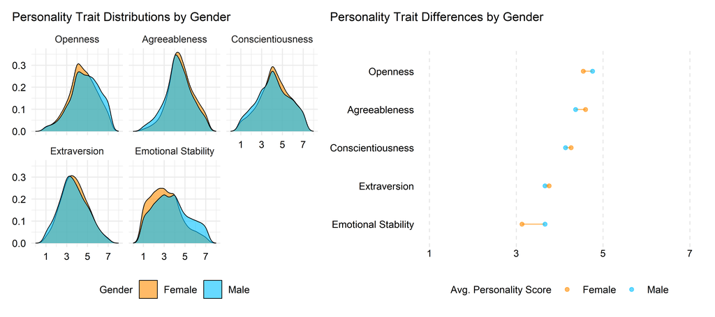

```r
# ====================================
# PERSONALITY DENSITY PLOT BY GENDER
# ====================================

personality = dass21 %>%
  # filter(gender != "Other") %>%
  select(gender, extraversion, agreeableness, conscientiousness, stability, openness) %>%
  pivot_longer(cols = -gender, names_to = "trait", values_to = "score") %>%
  mutate(
    trait = str_replace_all(trait, "stability", "Emotional Stability"),
    trait = str_to_title(trait),
    # Order the plots by factor to match personality diff graphic
    trait = factor(trait,
                   levels = c("Openness", "Agreeableness", "Conscientiousness",
                              "Extraversion", "Emotional Stability"))
  ) %>%
  ggplot(aes(x = score, fill = gender)) +
  geom_density(alpha = 0.6, bw = .3, linewidth = .3) +
  facet_wrap(~trait) +
  scale_fill_manual(values = c("Male" = "deepskyblue", "Female" = "darkorange")) +
  scale_x_continuous(breaks = seq(1, 7, by = 2), limits = c(0,8)) +
  theme_minimal() +
  labs(
    title = "Personality Trait Distributions by Gender",
    fill = "Gender"
  ) +
  theme(
    # Plot Level
    plot.title = element_text(size = 11, hjust = 0),
    plot.title.position = "plot",

    # Axes
    axis.title = element_blank(),
    axis.text.x = element_text(color = "black"),
    axis.text.y = element_text(color = "black", size = 9),

    # Legend
    legend.position = "bottom",
    legend.box = "horizontal",
    legend.title = element_text(color = "black", size = 9),
    legend.text = element_text(color = "black", size = 9)
  )

# ====================================
# BARBELL PLOT OF MEAN DIFFERENCES
# ====================================

personality_diff = dass21 %>%
  # filter(gender != "Other") %>%
  select(gender, extraversion, agreeableness, conscientiousness, stability, openness) %>%
  pivot_longer(cols = -gender, names_to = "trait", values_to = "score") %>%
  mutate(
    trait = str_replace_all(trait, "stability", "emotional stability"),
    trait = str_to_title(trait)) %>%
  group_by(trait, gender) %>%
  summarise(mean_score = mean(score, na.rm = TRUE), .groups = "drop") %>%
  pivot_wider(names_from = gender, values_from = mean_score) %>%
ggplot(aes(y = reorder(trait, Male))) +
  geom_segment(aes(
    x = Male,  xend = Female,
    y = trait, yend = trait),
    color = "darkorange",
    alpha = 0.6
    ) +
  geom_point(
    aes(x = Male, color = "Male"),
    size = 1.5, alpha = 0.6
    ) +
  geom_point(
    aes(x = Female, color = "Female"),
    size = 1.5, alpha = 0.6) +
  labs(
    title = "Personality Trait Differences by Gender",
    color = "Avg. Personality Score",
  ) +
  scale_color_manual(
    values = c("Male" = "deepskyblue",
               "Female" = "darkorange")
    ) +
  scale_x_continuous(breaks = seq(1, 7, by = 2), limits = c(1,7)) +
  theme(
    # Plot Level
    plot.title = element_text(size = 11, hjust = 0),
    plot.title.position = "plot",

    # Panel and Grid Lines
    panel.background = element_blank(),
    panel.border = element_blank(),
    panel.grid.major.x = element_line(color = "gray90", linewidth = 0.4, linetype = "dashed"),
    panel.grid.minor = element_blank(),

    # Axes
    axis.line = element_blank(),
    axis.title = element_blank(),
    axis.ticks = element_blank(),
    axis.text.x = element_text(color = "black"),
    axis.text.y = element_text(color = "black", size = 9),

    # Legend
    legend.position = "bottom",
    legend.box = "horizontal",
    legend.title = element_text(color = "black", size = 9),
    legend.text = element_text(color = "black", size = 9),
    legend.key = element_blank()
    )

combined_personality_plots = personality + personality_diff
combined_personality_plots
```

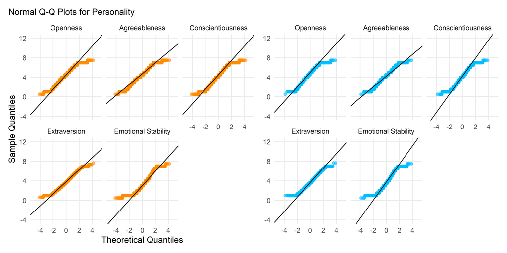

```r
# ====================================
# QQ PLOT FEMALE PERSONALITY
# ====================================

fqq_personality = dass21 %>%
  filter(gender == "Female") %>%
  select(gender, extraversion, agreeableness, conscientiousness, stability, openness) %>%
  pivot_longer(cols = -gender, names_to = "trait", values_to = "score") %>%
  mutate(
    trait = str_replace_all(trait, "stability", "Emotional Stability"),
    trait = str_to_title(trait),
    # Order the plots by factor to match personality diff graphic
    trait = factor(trait,
                   levels = c("Openness", "Agreeableness", "Conscientiousness",
                              "Extraversion", "Emotional Stability"))
  ) %>%
  ggplot(aes(sample = score)) +
  stat_qq(color = "darkorange", alpha = 0.6, size = 1.5) +
  stat_qq_line(color = "black") +
  facet_wrap(~ trait) + # Creates individual panels per trait
  labs(
    title = "Normal Q-Q Plots for Personality",
    x = "Theoretical Quantiles",
    y = "Sample Quantiles"
  ) +
  scale_x_continuous(breaks = seq(-4, 4, by = 2), limits = c(-5,5)) +
  scale_y_continuous(breaks = seq(-4, 12, by = 4), limits = c(-4,12)) +
  theme_minimal() +
  theme(
    # Plot Level
    plot.title = element_text(size = 11, hjust = 0),
    plot.title.position = "plot",

    # Panel and Grid Lines
    panel.background = element_blank(),
    panel.border = element_blank(),
    panel.grid.minor = element_blank(),

    # Axes
    axis.line = element_blank(),
    axis.ticks = element_blank(),
  )

# ====================================
# QQ PLOT MALE PERSONALITY
# ====================================

mqq_personality = dass21 %>%
  filter(gender == "Male") %>%
  select(gender, extraversion, agreeableness, conscientiousness, stability, openness) %>%
  pivot_longer(cols = -gender, names_to = "trait", values_to = "score") %>%
  mutate(
    trait = str_replace_all(trait, "stability", "Emotional Stability"),
    trait = str_to_title(trait),
    # Order the plots by factor to match personality diff graphic
    trait = factor(trait,
                   levels = c("Openness", "Agreeableness", "Conscientiousness",
                              "Extraversion", "Emotional Stability"))
  ) %>%
  ggplot(aes(sample = score)) +
  stat_qq(color = "deepskyblue", alpha = 0.6, size = 1.5) +
  stat_qq_line(color = "black") +
  facet_wrap(~ trait) +
  # labs(
  #   title = "Normal Q-Q Plots for Personality (Males)",
  #   x = "Theoretical Quantiles",
  #   y = "Sample Quantiles"
  # ) +
  scale_x_continuous(breaks = seq(-4, 4, by = 2), limits = c(-5,5)) +
  scale_y_continuous(breaks = seq(-4, 12, by = 4), limits = c(-4,12)) +
  theme_minimal() +
  theme(
    # Plot Level
    plot.title = element_text(size = 11, hjust = 0),
    plot.title.position = "plot",

    # Panel and Grid Lines
    panel.background = element_blank(),
    panel.border = element_blank(),
    panel.grid.minor = element_blank(),

    # Axes
    axis.line = element_blank(),
    axis.title = element_blank(),
    axis.ticks = element_blank(),
  )

combined_personality_qq = fqq_personality + mqq_personality
combined_personality_qq
```

### Depression, Anxiety, and Stress Differences

#### Table 5

##### Difference in Total DASS-21 Scores by Gender

```r
# 1. Define the explicit order and subscale matching maps
subscale_order <- c("stress21", "depres21", "anxiet21")

subscale_labels <- c(
  "stress21" = "Stress",
  "depres21" = "Depression",
  "anxiet21" = "Anxiety"
)

# 2. Extract, calculate, and flatten the data grid completely inside one tidy pipe
tidy_table_data <- dass21 %>%
  select(gender, all_of(subscale_order)) %>%
  filter(gender %in% c("Male", "Female")) %>%
  pivot_longer(cols = -gender, names_to = "subscale", values_to = "score") %>%
  drop_na() %>%
  group_by(subscale) %>%
  summarise(
    t_obj = list(t.test(score ~ gender, data = pick(everything()), var.equal = FALSE)),
    d_obj = list(cohens_d(score ~ gender, data = pick(everything()))),

    n_female  = sum(gender == "Female"),
    m_female  = sprintf("%.2f", mean(score[gender == "Female"])),
    sd_female = sprintf("%.2f", sd(score[gender == "Female"])),

    n_male    = sum(gender == "Male"),
    m_male    = sprintf("%.2f", mean(score[gender == "Male"])),
    sd_male   = sprintf("%.2f", sd(score[gender == "Male"])),
    .groups   = "drop"
  ) %>%
  mutate(
    t  = sprintf("%.2f", sapply(t_obj, function(x) x[["statistic"]])),
    df = sprintf("%.1f", sapply(t_obj, function(x) x[["parameter"]])),
    raw_p = sapply(t_obj, function(x) x[["p.value"]]),
    p  = ifelse(raw_p < 0.001, "< .001", sub("^0", "", sprintf("%.3f", raw_p))),
    d  = sprintf("%.2f", sapply(d_obj, function(x) x[["Cohens_d"]]))
  ) %>%
  group_by(subscale) %>%
  # Flatten the summaries into a 3-row layout per subscale
  reframe(
    Variable_and_Group = c(subscale_labels[subscale], "  Females", "  Males"),
    N  = c("", as.character(n_female), as.character(n_male)),
    M  = c("", m_female, m_male),
    SD = c("", sd_female, sd_male),
    t  = c(t, "", ""),
    df = c(df, "", ""),
    p  = c(p, "", ""),
    d  = c(d, "", "")
  ) %>%
  ungroup() %>%
  # FIXED: Create a temporary sorting helper column based on our target list rules
  mutate(sort_order = match(Variable_and_Group, subscale_labels)) %>%
  fill(sort_order, .direction = "down") %>%
  # Arrange using the helper variable, then clean up the tracking column
  arrange(sort_order) %>%
  select(-subscale, -sort_order)

# 3. Dynamically find the row locations that should be bold (rows 1, 4, and 7)
bold_row_indices <- which(tidy_table_data[["N"]] == "")

# 4. Render the final table with centered headers and right-aligned cell numbers
tidy_table_data %>%
  kbl(
    col.names = c("Variable and Group", "N", "M", "SD", "t", "df", "p", "Cohen's d"),
    align = c("l", "r", "r", "r", "r", "r", "r", "r"),
    booktabs = TRUE #,
    # caption = "Independent Samples t-Tests for DASS-21 Subscales Split by Gender"
  ) %>%
  kable_styling(
    font_size = 16,
    html_font = "Times New Roman",
    bootstrap_options = c("striped", "hover"),
    latex_options = "striped",
    full_width = TRUE
  ) %>%
  column_spec(1, width = "30%") %>%
  column_spec(2:8, width = "10%") %>%
  row_spec(0, align = "c") %>%
  row_spec(bold_row_indices, bold = TRUE)
```

| Variable and Group | N | M | SD | t | df | p | Cohen’s d |
| --- | --- | --- | --- | --- | --- | --- | --- |
| Stress |  |  |  | 27.78 | 13806.2 | < .001 | 0.34 |
| Females | 30156 | 22.61 | 10.70 |  |  |  |  |
| Males | 8679 | 18.92 | 10.94 |  |  |  |  |
| Depression |  |  |  | 7.78 | 13810.2 | < .001 | 0.10 |
| Females | 30156 | 21.17 | 12.68 |  |  |  |  |
| Males | 8679 | 19.95 | 12.96 |  |  |  |  |
| Anxiety |  |  |  | 26.17 | 14612.5 | < .001 | 0.31 |
| Females | 30156 | 16.26 | 10.47 |  |  |  |  |
| Males | 8679 | 13.04 | 9.99 |  |  |  |  |

###### *Note.* *M* = Mean; *SD* = Standard Deviation.

#### Fig. 3

##### Depression, Anxiety, Stress Difference Plots

[figure not shown]

```r
# ====================================
# PERSONALITY DENSITY PLOT BY GENDER
# ====================================

dass_gender_dist = dass21 %>%
  # filter(gender != "Other") %>%
  select(gender, depres21, stress21, anxiet21) %>%
  pivot_longer(cols = -gender, names_to = "scale", values_to = "score") %>%
  mutate(
    scale = str_replace_all(scale, c("anxiet21" = "Anxiety",
                                     "depres21" = "Depression",
                                     "stress21" = "Stress")),
    scale = factor(scale, levels = c("Stress", "Depression", "Anxiety"))
    ) %>%
  ggplot(aes(x = score, fill = gender)) +
  geom_density(alpha = 0.6, bw = 2, linewidth = .3) +
  facet_wrap(~scale) +
  scale_fill_manual(values = c("Male" = "deepskyblue", "Female" = "darkorange")) +
  scale_x_continuous(breaks = seq(0, 45, by = 10), limits = c(-5,45)) +
  theme_minimal() +
  labs(
    title = "DASS Distributions by Gender",
    caption = "Scales ordered high to low by gender differences",
    fill = "Gender"
  ) +
  theme(
    # Plot Level
    plot.title = element_text(size = 11, hjust = 0),
    plot.title.position = "plot",
    plot.caption  = element_text(size = 8, hjust = 0),

    # Axes
    axis.title = element_blank(),
    axis.text.x = element_text(color = "black"),
    axis.text.y = element_text(color = "black", size = 9),

    # Legend
    legend.position = "bottom",
    legend.box = "horizontal",
    legend.title = element_text(color = "black", size = 9),
    legend.text = element_text(color = "black", size = 9)
  )

# ====================================
# BARBELL PLOT OF MEAN DIFFERENCES
# ====================================

dass_gender_diff = dass21 %>%
  # filter(gender != "Other") %>%
  select(gender, depres21, stress21, anxiet21) %>%
  pivot_longer(cols = -gender, names_to = "scale", values_to = "score") %>%
  mutate(
    scale = str_replace_all(
      scale,
      c("anxiet21" = "Anxiety", "depres21" = "Depression", "stress21" = "Stress"))
    ) %>%
  group_by(scale, gender) %>%
  summarise(mean_score = mean(score, na.rm = TRUE), .groups = "drop") %>%
  pivot_wider(names_from = gender, values_from = mean_score) %>%
ggplot(aes(y = reorder(scale, Female))) +
  geom_segment(aes(
    x = Male,  xend = Female,
    y = scale, yend = scale),
    color = "darkorange",
    alpha = 0.6
    ) +
  geom_point(
    aes(x = Male, color = "Male"),
    size = 1.5, alpha = 0.6
    ) +
  geom_point(
    aes(x = Female, color = "Female"),
    size = 1.5, alpha = 0.6) +
  labs(
    title = "DASS Differences by Gender",
    caption = "Scales ordered high to low by gender differences",
    color = "Avg. Personality Score",
  ) +
  scale_color_manual(
    values = c("Male" = "deepskyblue",
               "Female" = "darkorange")
    ) +
  scale_x_continuous(breaks = seq(0, 45, by = 10), limits = c(0,45)) +
  theme(
    # Plot Level
    plot.title = element_text(size = 11, hjust = 0),
    plot.title.position = "plot",
    plot.caption  = element_text(size = 8, hjust = 0),

    # Panel and Grid Lines
    panel.background = element_blank(),
    panel.border = element_blank(),
    panel.grid.major.x = element_line(color = "gray90", linewidth = 0.4, linetype = "dashed"),
    panel.grid.minor = element_blank(),

    # Axes
    axis.line = element_blank(),
    axis.title = element_blank(),
    axis.ticks = element_blank(),
    axis.text.x = element_text(color = "black"),
    axis.text.y = element_text(color = "black", size = 9),

    # Legend
    legend.position = "bottom",
    legend.box = "horizontal",
    legend.title = element_text(color = "black", size = 9),
    legend.text = element_text(color = "black", size = 9),
    legend.key = element_blank()
    )

combined_personality_plots = dass_gender_dist + dass_gender_diff
combined_personality_plots
```

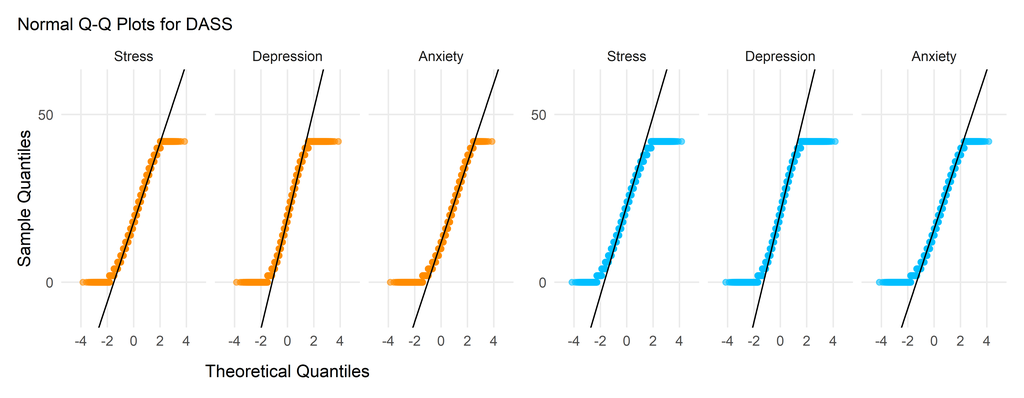

```r
# ====================================
# QQ PLOT FEMALE DASS
# ====================================

fqq_dass = dass21 %>%
  filter(gender != "Female") %>%
  select(gender, depres21, stress21, anxiet21) %>%
  pivot_longer(cols = -gender, names_to = "scale", values_to = "score") %>%
  mutate(
    scale = str_replace_all(scale, c("anxiet21" = "Anxiety",
                                     "depres21" = "Depression",
                                     "stress21" = "Stress")),
    scale = factor(scale, levels = c("Stress", "Depression", "Anxiety"))
    ) %>%
  ggplot(aes(sample = score)) +
  stat_qq(color = "darkorange", alpha = 0.6, size = 1.5) +
  stat_qq_line(color = "black") +
  facet_wrap(~ scale) +
  labs(
    title = "Normal Q-Q Plots for DASS",
    x = "Theoretical Quantiles",
    y = "Sample Quantiles"
  ) +
  theme_minimal() +
  scale_x_continuous(breaks = seq(-4, 4, by = 2), limits = c(-5,5)) +
  scale_y_continuous(breaks = seq(-50, 50, by = 50), limits = c(-10,60)) +
  theme(
    # Plot Level
    plot.title = element_text(size = 11, hjust = 0),
    plot.title.position = "plot",

    # Panel and Grid Lines
    panel.background = element_blank(),
    panel.border = element_blank(),
    panel.grid.minor = element_blank(),

    # Axes
    axis.line = element_blank(),
    axis.ticks = element_blank(),
    axis.title.x = element_text(margin = margin(t = 10))
  )

# ====================================
# QQ PLOT MALE DASS
# ====================================

mqq_dass = dass21 %>%
  filter(gender != "Male") %>%
  select(gender, depres21, stress21, anxiet21) %>%
  pivot_longer(cols = -gender, names_to = "scale", values_to = "score") %>%
  mutate(
    scale = str_replace_all(scale, c("anxiet21" = "Anxiety",
                                     "depres21" = "Depression",
                                     "stress21" = "Stress")),
    scale = factor(scale, levels = c("Stress", "Depression", "Anxiety"))
    ) %>%
  ggplot(aes(sample = score)) +
  stat_qq(color = "deepskyblue", alpha = 0.6, size = 1.5) +
  stat_qq_line(color = "black") +
  facet_wrap(~ scale) +
  # labs(
  #   title = "Normal Q-Q Plots for DASS (Males)",
  #   x = "Theoretical Quantiles",
  #   y = "Sample Quantiles"
  # ) +
  scale_x_continuous(breaks = seq(-4, 4, by = 2), limits = c(-5,5)) +
  scale_y_continuous(breaks = seq(-50, 50, by = 50), limits = c(-10,60)) +
  theme_minimal() +
  theme(
    # Plot Level
    plot.title = element_text(size = 11, hjust = 0),
    plot.title.position = "plot",

    # Panel and Grid Lines
    panel.background = element_blank(),
    panel.border = element_blank(),
    panel.grid.minor = element_blank(),

    # Axes
    axis.line = element_blank(),
    axis.title = element_blank(),
    axis.ticks = element_blank(),
  )

combined_dass_qq = fqq_dass + mqq_dass
combined_dass_qq
```

## Regression

### Personality Traits as Predictors of Stress, Depression, and Anxiety

```r
# ====================================
# REGRESSION MODELS: FEMALES
# ====================================

lm_fstress = lm(
  stress21 ~ extraversion + agreeableness + conscientiousness + stability + openness,
  data = dass21 %>%
    filter(gender == "Female") %>%
    select(stress21, extraversion, agreeableness, conscientiousness, stability, openness)
)

lm_fdepress = lm(
  depres21 ~ extraversion + agreeableness + conscientiousness + stability + openness,
  data = dass21 %>%
    filter(gender == "Female") %>%
    select(depres21, extraversion, agreeableness, conscientiousness, stability, openness)
)

lm_fanxiety = lm(
  anxiet21 ~ extraversion + agreeableness + conscientiousness + stability + openness,
  data = dass21 %>%
    filter(gender == "Female") %>%
    select(anxiet21, extraversion, agreeableness, conscientiousness, stability, openness)
)

# ====================================
# REGRESSION MODELS: MALES
# ====================================

lm_mstress = lm(
  stress21 ~ extraversion + agreeableness + conscientiousness + stability + openness,
  data = dass21 %>%
    filter(gender == "Male") %>%
    select(stress21, extraversion, agreeableness, conscientiousness, stability, openness)
)

lm_mdepress = lm(
  depres21 ~ extraversion + agreeableness + conscientiousness + stability + openness,
  data = dass21 %>%
    filter(gender == "Male") %>%
    select(depres21, extraversion, agreeableness, conscientiousness, stability, openness)
)

lm_manxiety = lm(
  anxiet21 ~ extraversion + agreeableness + conscientiousness + stability + openness,
  data = dass21 %>%
    filter(gender == "Male") %>%
    select(anxiet21, extraversion, agreeableness, conscientiousness, stability, openness)
)
```

Multiple regression analyses were conducted to examine how personality traits predict stress, depression, and anxiety by gender. Models were created using the built in `lm()` function in R, where personality traits were predictors of stress, depression and anxiety for females and males, respectively (e.g., `stress ~ extraversion + ... + openness`). Full results are reported in Table 6, with unstandarized regression coefficients visualized by gender in Fig. 4.

Stress. The regression models explained a substantial amount of variance in stress for both females $(R^2 = .40)$ and males $(R^2 = .43)$. Emotional Stability was the strongest predictor of lower stress levels for both females $(B = -4.25, t = -120.64, p < .001)$ and males $(B = -4.17, t = -71.07, p < .001)$. All other personality traits significantly predicted lower stress in females $(p < .001)$. For males, however, Openness $(B = -0.22, t = -2.74, p = .006)$ and Agreeableness $(B = -0.32, t = -4.46, p < .001)$ were significant predictors, while Conscientiousness $(p = .077)$ and Extraversion $(p = .074)$ did not reach statistical significance.

Depression. The overall variance explained in depression was similar between the groups, accounting for 31% in females $(R^2 = .31)$ and 34% in males $(R^2 = .34)$. Emotional Stability was again the strongest predictor of lower depression for both females $(B = -3.78, t = -84.65, p < .001)$ and males $(B = -3.37, t = -45.07, p < .001)$. Agreeableness, Conscientiousness, and Extraversion were highly significant predictors of lower depression across both genders $(p < .001)$. Openness did not significantly predict depression for either females $(B = 0.08, t = 1.44, p = .149)$ or males $(B = 0.04, t = 0.40, p = .688)$.

Anxiety. Personality traits predicted 24% of the variance in anxiety for females $(R^2 = .24)$ and 27% for males $(R^2 = .27)$. Emotional Stability consistently served as the strongest predictor of lower anxiety for females $(B = -3.06, t = -79.08, p < .001)$ and males $(B = -2.88, t = -47.54, p < .001)$. While Openness, Conscientiousness, and Extraversion predicted lower anxiety levels across both groups $(p \le .005)$, Agreeableness showed a diverging pattern: it predicted significantly lower anxiety in females $(B = -0.18, t = -3.87, p < .001)$ but significantly higher anxiety in males $(B = 0.29, t = 4.00, p < .001)$.

#### Table 6

##### Personality Traits as Predictors of Stress, Depression, and Anxiety

```r
# ====================================
# MULTIPLE REGRESSION RESULTS
# ====================================

# 1. Place your model objects into a structured named list
model_list <- list(
  "Stress_Female"     = lm_fstress,
  "Stress_Male"       = lm_mstress,
  "Depression_Female" = lm_fdepress,
  "Depression_Male"   = lm_mdepress,
  "Anxiety_Female"    = lm_fanxiety,
  "Anxiety_Male"      = lm_manxiety
)

# Predictor clean names map
predictor_labels <- c(
  "(Intercept)"       = "Intercept",
  "extraversion"      = "Extraversion",
  "agreeableness"     = "Agreeableness",
  "conscientiousness" = "Conscientiousness",
  "stability"         = "Emotional Stability",
  "openness"          = "Openness"
)

# 2. Extract and shape statistics into a wide format (side-by-side)
extracted_data <- imap_dfr(model_list, function(model, name) {
  name_parts   <- unlist(strsplit(name, "_"))
  outcome_type <- name_parts[1]
  gender_type  <- name_parts[2]

  sum_mod     <- summary(model)
  coef_matrix <- sum_mod$coefficients

  data.frame(
    Outcome   = outcome_type,
    Gender    = gender_type,
    term      = rownames(coef_matrix),
    b         = sprintf("%.2f", coef_matrix[, "Estimate"]),
    t_val     = sprintf("%.2f", coef_matrix[, "t value"]),
    raw_p     = coef_matrix[, "Pr(>|t|)"],
    r_sq      = sprintf("%.2f", sum_mod$r.squared),
    stringsAsFactors = FALSE
  )
}) %>%
  mutate(
    p = ifelse(raw_p < 0.001, "< .001", sub("^0", "", sprintf("%.3f", raw_p))),
    Variable_Label = predictor_labels[term]
  )

# Pivot wide so Female and Male stats sit on the exact same row
wide_table_data <- extracted_data %>%
  select(Outcome, Variable_Label, Gender, b, t_val, p, r_sq) %>%
  pivot_wider(
    id_cols = c(Outcome, Variable_Label),
    names_from = Gender,
    values_from = c(b, t_val, p, r_sq)
  )

# 3. Build the flat table structure row-by-row
table_rows <- list()
bold_indices <- c()
current_row <- 1
list_counter <- 1

outcomes_order <- c("Stress", "Depression", "Anxiety")
predictors_order <- c("Intercept", "Openness", "Agreeableness", "Conscientiousness", "Extraversion", "Emotional Stability")

for (out in outcomes_order) {
  sub_data <- wide_table_data %>% filter(Outcome == out)

  if (nrow(sub_data) > 0) {
    # Extract R2 values for the header row
    r2_f <- sub_data$r_sq_Female[1]
    r2_m <- sub_data$r_sq_Male[1]

    # Row A: The main bold outcome block header showing model fits
    outcome_header <- data.frame(
      Label = toupper(out),
      b_F = "", t_F = "", p_F = paste0("R² = ", r2_f),
      b_M = "", t_M = "", p_M = paste0("R² = ", r2_m),
      stringsAsFactors = FALSE
    )
    bold_indices <- c(bold_indices, current_row)
    current_row <- current_row + 1
    table_rows[[list_counter]] <- outcome_header
    list_counter <- list_counter + 1

    # Sort predictors consistently
    sub_data <- sub_data %>%
      mutate(Variable_Label = factor(Variable_Label, levels = predictors_order)) %>%
      arrange(Variable_Label)

    # Rows B-G: Predictor data rows
    predictor_rows <- data.frame(
      Label = paste0("  ", sub_data$Variable_Label),
      b_F   = sub_data$b_Female,
      t_F   = sub_data$t_val_Female,
      p_F   = sub_data$p_Female,
      b_M   = sub_data$b_Male,
      t_M   = sub_data$t_val_Male,
      p_M   = sub_data$p_Male,
      stringsAsFactors = FALSE
    )
    current_row <- current_row + nrow(predictor_rows)
    table_rows[[list_counter]] <- predictor_rows
    list_counter <- list_counter + 1
  }
}

formatted_side_by_side <- bind_rows(table_rows)

# 4. Render the side-by-side table with spanned header groupings
formatted_side_by_side %>%
  kbl(
    col.names = c("Predictor Variable", "B", "t", "p", "B", "t", "p"),
    align = c("l", "r", "r", "r", "r", "r", "r"),
    booktabs = TRUE,
    escape = FALSE
  ) %>%
  kable_styling(
    font_size = 15,
    html_font = "Times New Roman",
    bootstrap_options = c("striped", "hover"),
    latex_options = "striped",
    full_width = TRUE
  ) %>%
  # Span column headers over the statistics
  add_header_above(c(" " = 1, "Female Regression Models" = 3, "Male Regression Models" = 3), bold = TRUE) %>%
  column_spec(1, width = "34%") %>%
  column_spec(2:7, width = "11%") %>%
  row_spec(0, align = "c") %>%
  row_spec(bold_indices, bold = TRUE)
```

| Predictor Variable | Female Regression Models B | Female Regression Models t | Female Regression Models p | Male Regression Models B | Male Regression Models t | Male Regression Models p |
| --- | --- | --- | --- | --- | --- | --- |
| STRESS |  |  | R² = 0.40 |  |  | R² = 0.43 |
| Intercept | 41.92 | 160.51 | < .001 | 37.65 | 83.33 | < .001 |
| Openness | -0.16 | -3.56 | < .001 | -0.22 | -2.74 | .006 |
| Agreeableness | -0.51 | -12.25 | < .001 | -0.32 | -4.46 | < .001 |
| Conscientiousness | -0.37 | -10.59 | < .001 | -0.11 | -1.77 | .077 |
| Extraversion | -0.37 | -7.76 | < .001 | -0.15 | -1.79 | .074 |
| Emotional Stability | -4.25 | -120.64 | < .001 | -4.17 | -71.07 | < .001 |
| DEPRESSION |  |  | R² = 0.31 |  |  | R² = 0.34 |
| Intercept | 45.92 | 138.81 | < .001 | 45.92 | 79.62 | < .001 |
| Openness | 0.08 | 1.44 | .149 | 0.04 | 0.40 | .688 |
| Agreeableness | -0.49 | -9.38 | < .001 | -0.40 | -4.42 | < .001 |
| Conscientiousness | -1.06 | -24.26 | < .001 | -1.05 | -13.43 | < .001 |
| Extraversion | -1.74 | -28.95 | < .001 | -2.11 | -19.38 | < .001 |
| Emotional Stability | -3.78 | -84.65 | < .001 | -3.37 | -45.07 | < .001 |
| ANXIETY |  |  | R² = 0.24 |  |  | R² = 0.27 |
| Intercept | 32.17 | 112.19 | < .001 | 26.85 | 57.59 | < .001 |
| Openness | -0.14 | -2.79 | .005 | -0.41 | -4.82 | < .001 |
| Agreeableness | -0.18 | -3.87 | < .001 | 0.29 | 4.00 | < .001 |
| Conscientiousness | -0.57 | -15.12 | < .001 | -0.35 | -5.60 | < .001 |
| Extraversion | -0.65 | -12.56 | < .001 | -0.31 | -3.58 | < .001 |
| Emotional Stability | -3.06 | -79.08 | < .001 | -2.88 | -47.54 | < .001 |

###### *Note.* *B* = unstandardized regression coefficient.

#### Fig. 4

#### Personality Traits Predictors of Stress, Depression, Anxiety

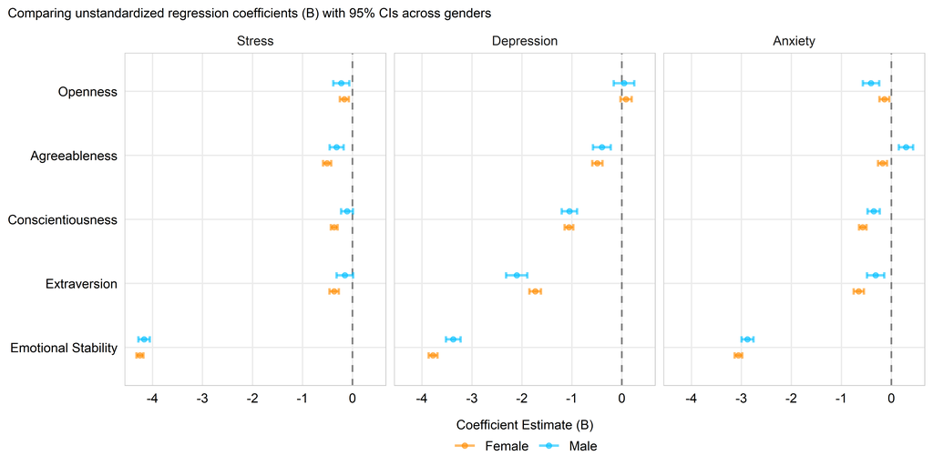

```r
# 1. Place your model objects into a structured named list
model_list <- list(
  "Stress_Female"     = lm_fstress,
  "Stress_Male"       = lm_mstress,
  "Depression_Female" = lm_fdepress,
  "Depression_Male"   = lm_mdepress,
  "Anxiety_Female"    = lm_fanxiety,
  "Anxiety_Male"      = lm_manxiety
)

# Predictor clean names map (excluding Intercept for cleaner visual scaling)
predictor_labels <- c(
  "openness"          = "Openness",
  "agreeableness"     = "Agreeableness",
  "conscientiousness" = "Conscientiousness",
  "extraversion"      = "Extraversion",
  "stability"         = "Emotional Stability"
)

# 2. Extract estimates and 95% Confidence Intervals programmatically
plot_data <- imap_dfr(model_list, function(model, name) {
  name_parts   <- unlist(strsplit(name, "_"))
  outcome_type <- name_parts[1]
  gender_type  <- name_parts[2]

  # Extract coefficients and confidence intervals
  coef_df <- as.data.frame(summary(model)$coefficients)
  ci_df   <- as.data.frame(confint(model))

  data.frame(
    Outcome   = outcome_type,
    Gender    = gender_type,
    term      = rownames(coef_df),
    Estimate  = coef_df[, "Estimate"],
    Lower_CI  = ci_df[, 1],
    Upper_CI  = ci_df[, 2],
    stringsAsFactors = FALSE
  )
}) %>%
  # Filter out the intercept so it doesn't skew the visual scale
  filter(term %in% names(predictor_labels)) %>%
  mutate(
    Variable_Label = predictor_labels[term],
    # Factor to control the exact vertical ordering of the traits
    Variable_Label = factor(Variable_Label, levels = rev(c("Openness", "Agreeableness", "Conscientiousness",
                                                           "Extraversion", "Emotional Stability"))),
    Outcome = factor(Outcome, levels = c("Stress", "Depression", "Anxiety"))
  )

# 3. Create the Coefficient Plot (Updated for ggplot2 4.0.0+)
ggplot(plot_data, aes(x = Estimate, y = Variable_Label, color = Gender)) +
  # Add a vertical reference line at 0 (indicating no effect)
  geom_vline(xintercept = 0, linetype = "dashed", color = "gray50", linewidth = 0.6) +
  # Use geom_errorbar instead of geom_errorbarh (automatically detects horizontal orientation)
  geom_errorbar(aes(xmin = Lower_CI, xmax = Upper_CI),
                width = 0.2,
                linewidth = 0.8,
                alpha = 0.6,
                position = position_dodge(width = 0.5)) +
  # Draw the point estimates
  geom_point(size = 1.5, alpha = 0.6, position = position_dodge(width = 0.5)) +
  # Split the layout into separate columns by Mental Health Outcome
  facet_grid(. ~ Outcome) +
  # Custom clean styling matching APA-like presentation
  scale_color_manual(values = c("Female" = "darkorange", "Male" = "deepskyblue")) +
  labs(
    # title = "Personality Traits Predictors of Stress, Depression, Anxiety",
    subtitle = "Comparing unstandardized regression coefficients (B) with 95% CIs across genders",
    x = "Coefficient Estimate (B)",
    y = "Personality Trait"
  ) +
  theme_minimal() +
  theme(
    # Plot Level
    plot.title = element_text(size = 11, hjust = 0),
    plot.title.position = "plot",
    plot.subtitle = element_text(size = 9, hjust = 0, color = "black"),

    # Panel & Grid
    panel.border = element_rect(color = "gray80", fill = NA, linewidth = 0.5),
    panel.grid.minor = element_blank(),

    # Facet Strips
    strip.text = element_text(size = 9),

    # Axes
    axis.title.y = element_blank(),
    axis.title.x = element_text(
      color = "black",
      size = 9,
      margin = margin(t = 10)
    ),
    axis.text.x = element_text(
      color = "black",
      size = 9,
      ),
    axis.text.y = element_text(color = "black", size = 9),

    # Legend
    legend.position = "bottom",
    legend.box = "horizontal",
    legend.title = element_blank(),
    legend.text = element_text(color = "black", size = 9),
    legend.margin = margin(t = -10)
  )
```

# Discussion

The findings in this study largely replicated previous findings. For multi-group CFA, analyses showed the configural model for 42-item DASS scale did not achieve good fit. After accounting for highly correlated subscales, the adjusted 42-item scale achieved good fit and demonstrated full invariance across each model (i.e., weak, strong, strict), thereby replicating research by Gomez et al. (2014) and Lu at al. (2018). This study further replicated findings by Lippa (2010) and Weisberg et al. (2011) who found small to moderate differences in personality where females, compared to males, reported higher average scores on trait agreeableness and lower average scores on trait emotional stability. Additionally, this study replicated research by Alizadeh et al. (2018) and Uliaszek et al. (2010) who found emotional stability was the best predictor of mental health indicators for males and females. Similarly, although females reported higher scores on across each indicator compared to males, these differences tended to be small to moderate, and personality was a better predictor of stress, anxiety, and depression for males compared to females.

## Limitations

The foremost limitation is that of the survey design. Participants were selected via convenience sampling (e.g., may have sought out the survey or happened on it by accident). Further, anonimous survey completion means that the same person could have completed the survey multiple times. A second limitation is that of project constraints. This project required a large data set, which meant that reducing the sample size by filtering for unique locations and dropping outlier completion times, then conducting random sampling would have been too restrictive. To maintain parody across projects (e.g., the machine learning component, sample parity was required), such methodological improvements were not possible. Finally, researcher domain knowledge was extensively tested, often encountering vast limitations which were addressed by engaging relevant literature. Candidly, this was an ambitious project for one person to complete. Although, it was completed with the utmost care and with an eye toward accuracy, either a lack of domain knowledge or human error may have introduced errors in the analyses.

## Future Directions

With corrections to sampling and a narrower scope, this data set offers a tremendous avenues of research. For example, relationship between DASS-21 indicators of mental health and education level could be explored. Alternatively, contrasts between majors could be made (e.g., do college graduates with humanities majors experience difference levels of stress compared to STEM majors?). Personality differences between males and females and college major could even be explored. Given the rich selection of variables, researchers may find more studies to replicate on differences between religious and irreligious populations.

# Exploratory Data Analysis

## Demographic EDA

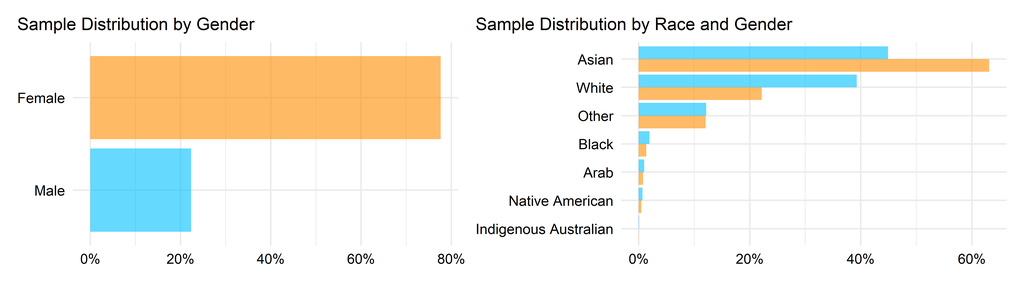

```r
# ====================================
# SAMPLE PROPORTION BY GENDER
# ====================================

gender_dist = dass21 %>%
  select(gender) %>%
  # filter(!is.na(gender), gender != "Other") %>%
  mutate(total_overall = n()) %>%
  group_by(gender) %>%
  summarize(
    proportion = n() / total_overall[1]
  ) %>%
  ggplot(aes(x = fct_rev(fct_infreq(gender)), y = proportion, fill = gender)) +
  geom_col(alpha = 0.6) +
  scale_fill_manual(values = c("Male" = "deepskyblue", "Female" = "darkorange")) +
  scale_y_continuous(labels = scales::percent) +
  labs(title = "Sample Distribution by Gender") +
  coord_flip() +
  theme_minimal() +
  theme(
    # Plot Level
    plot.title = element_text(size = 11, hjust = 0),
    plot.title.position = "plot",

    # Axes
    axis.title = element_blank(),
    axis.text.x = element_text(color = "black"),
    axis.text.y = element_text(color = "black", size = 9),

    # Legend
    legend.position = "none"
    # legend.title = element_text(color = "black", size = 9),
    # legend.text = element_text(color = "black", size = 9)
        )

# ====================================
# SAMPLE DIST. BY RACE AND GENDER
# ====================================

race_gender_dist = dass21 %>%
  filter(!is.na(race), !is.na(gender), gender != "Other") %>%
  count(gender, race, name = "count") %>%
  group_by(gender) %>%
  mutate(proportion = count / sum(count)) %>%
  ungroup() %>%
  ggplot(aes(x = reorder(race, proportion), y = proportion, fill = gender)) +
  geom_col(alpha = 0.6, position = "dodge", show.legend = TRUE) +
  scale_fill_manual(values = c("Male" = "deepskyblue",
                               "Female" = "darkorange")) +

  scale_y_continuous(labels = scales::percent_format(accuracy = 1)) +
  labs(title = "Sample Distribution by Race and Gender") +
  coord_flip() +
  theme_minimal() +
  theme(
    # Plot Level
    plot.title = element_text(size = 11, hjust = 0),
    plot.title.position = "plot",

    # Axes
    axis.title = element_blank(),
    axis.text.x = element_text(color = "black"),
    axis.text.y = element_text(color = "black", size = 9),

    # Legend
    legend.position = "none"
    # legend.title = element_text(color = "black", size = 9),
    # legend.text = element_text(color = "black", size = 9)
        )

combined_gender_dist_plots = gender_dist + race_gender_dist
combined_gender_dist_plots
```

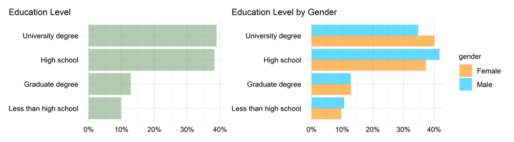

```r
# ====================================
# EDUCATION LEVEL PLOT
# ====================================

education_lvl = dass21 %>%
  filter(!is.na(education)) %>%
  count(education, name = "count") %>%
  mutate(proportion = count / sum(count)) %>%
  ggplot(aes(x = reorder(education, proportion), y = proportion)) +
  geom_col(fill = "#80A680", alpha = 0.6) +
  scale_y_continuous(labels = scales::percent_format(accuracy = 1)) +
  labs(title = "Education Level") +
  coord_flip() +
  theme_minimal() +
  theme(
    # Plot Level
    plot.title = element_text(size = 11, hjust = 0),
    plot.title.position = "plot",

    # Axes
    axis.title = element_blank(),
    axis.text.x = element_text(color = "black"),
    axis.text.y = element_text(color = "black", size = 9),

    # Legend
    legend.title = element_text(color = "black", size = 9),
    legend.text = element_text(color = "black", size = 9)
    )

# ====================================
# EDUCATION LEVEL BY GENDER PLOT
# ====================================

education_lvl_gender = dass21 %>%
  filter(!is.na(education), !is.na(gender), gender != "Other") %>%
  count(gender, education, name = "count") %>%
  group_by(gender) %>%
  mutate(
    proportion = count / sum(count)) %>%
  ungroup() %>%
  # Reorder education factor to match other plot.  Use rev() to account for coord_flip.
  mutate(
    education = factor(education,
                       levels = rev(c("University degree", "High school",
                                      "Graduate degree", "Less than high school")))
    ) %>%
  ggplot(aes(x = education, y = proportion, fill = gender)) +
  geom_col(alpha = 0.6, position = "dodge", show.legend = TRUE) +
  scale_fill_manual(values = c("Male" = "deepskyblue",
                               "Female" = "darkorange")) +

  scale_y_continuous(labels = scales::percent_format(accuracy = 1)) +
  labs(title = "Education Level by Gender") +
  coord_flip() +
  theme_minimal() +
  theme(
    # Plot Level
    plot.title = element_text(size = 11, hjust = 0),
    plot.title.position = "plot",

    # Axes
    axis.title = element_blank(),
    axis.text.x = element_text(color = "black"),
    axis.text.y = element_text(color = "black", size = 9),

    # Legend
    legend.title = element_text(color = "black", size = 9),
    legend.text = element_text(color = "black", size = 9)
        )

combined_ed_level_plots = education_lvl + education_lvl_gender
combined_ed_level_plots
```

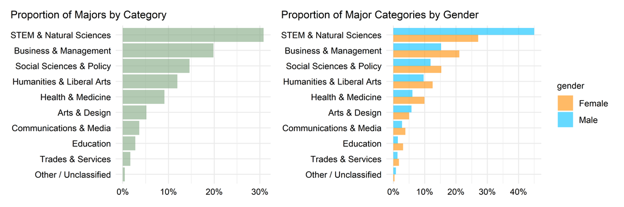

```r
# ====================================
# MAJOR CATEGORY PLOT
# ====================================

majors_cat = dass21 %>%
  filter(!is.na(major_cat)) %>%
  count(major_cat, name = "count") %>%
  mutate(proportion = count / sum(count)) %>%
  ggplot(aes(x = reorder(major_cat, proportion), y = proportion)) +
  geom_col(fill = "#80A680", alpha = 0.6) +
  scale_y_continuous(labels = scales::percent_format(accuracy = 1)) +
  coord_flip() +
  labs(title = "Proportion of Majors by Category") +
  theme_minimal() +
  theme(
    # Plot Level
    plot.title.position = "plot",
    plot.title = element_text(size = 11, hjust = 0),

    # Axes
    axis.title = element_blank(),
    axis.text.x = element_text(color = "black"),
    axis.text.y = element_text(color = "black", size = 9),

    # Legend
    legend.title = element_text(color = "black", size = 9),
    legend.text = element_text(color = "black", size = 9)
        )

# ====================================
# MAJOR CATEGORY BY GENDER PLOT
# ====================================

majors_gender = dass21 %>%
  select(gender, major_cat) %>%
  filter(!is.na(gender), !is.na(major_cat), gender != "Other") %>%
  group_by(gender) %>%
  mutate(total_in_gender = n()) %>%
  group_by(gender, major_cat) %>%
  summarize(proportion = n() / total_in_gender[1], .groups = "drop") %>%
  ggplot(aes(x = fct_reorder(major_cat, proportion, .desc = FALSE),
             y = proportion,
             fill = gender)) +
  scale_fill_manual(values = c("Male" = "deepskyblue",
                    "Female" = "darkorange")) +
  geom_col(position = "dodge", alpha = .6) +
  scale_y_continuous(labels = scales::percent) +
  labs(title = "Proportion of Major Categories by Gender") +
  theme_minimal() +
  theme(
    # Plot Level
    plot.title.position = "plot",
    plot.title = element_text(size = 11, hjust = 0),

    # Axes
    axis.title = element_blank(),
    axis.text.x = element_text(color = "black"),
    axis.text.y = element_text(color = "black", size = 9),

    # Legend
    legend.title = element_text(color = "black", size = 9),
    legend.text = element_text(color = "black", size = 9)
    ) +
  coord_flip()

combined_major_plots = majors_cat + majors_gender
combined_major_plots
```

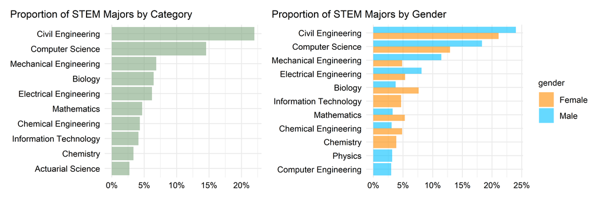

```r
# ====================================
# STEM MAJORS PLOT
# ====================================

stem_majors = dass21 %>%
  filter(major_cat == "STEM & Natural Sciences", !is.na(major_std)) %>%
  count(major_std, name = "count") %>%
  mutate(proportion = count / sum(count)) %>%
  mutate(major_std = str_to_title(major_std)) %>%
  slice_max(proportion, n = 10) %>%
  ggplot(aes(x = reorder(major_std, proportion), y = proportion)) +
  geom_col(fill = "#80A680", alpha = 0.6) +
  scale_y_continuous(labels = scales::percent_format(accuracy = 1)) +
  labs(title = "Proportion of STEM Majors by Category") +
  coord_flip() +
  theme_minimal() +
  theme(
    # Plot Level
    plot.title.position = "plot",
    plot.title = element_text(size = 11, hjust = 0),

    # Axes
    axis.title = element_blank(),
    axis.text.x = element_text(color = "black"),
    axis.text.y = element_text(color = "black", size = 9),

    # Legend
    legend.title = element_text(color = "black", size = 9),
    legend.text = element_text(color = "black", size = 9)
        )

# ====================================
# STEM MAJORS BY GENDER PLOT
# ====================================

stem_gender = dass21 %>%
  filter(major_cat == "STEM & Natural Sciences",
         !is.na(major_std),
         !is.na(gender),
         gender != "Other") %>%
  count(gender, major_std, name = "count") %>%
  group_by(gender) %>%
  mutate(proportion = count / sum(count)) %>%
  ungroup() %>%
  mutate(major_std = str_to_title(major_std)) %>%
  group_by(gender) %>%
  slice_max(proportion, n = 9, with_ties = FALSE) %>%
  ungroup() %>%
  ggplot(aes(x = reorder(major_std, proportion), y = proportion, fill = gender)) +
  geom_col(alpha = 0.6, position = "dodge") +
  scale_fill_manual(values = c("Male" = "deepskyblue", "Female" = "darkorange")) +
  labs(title = "Proportion of STEM Majors by Gender") +
  scale_y_continuous(labels = scales::percent_format(accuracy = 1)) +
  coord_flip() +
  theme_minimal() +
  theme(
    # Plot Level
    plot.title.position = "plot",
    plot.title = element_text(size = 11, hjust = 0),

    # Axes
    axis.title = element_blank(),
    axis.text.x = element_text(color = "black"),
    axis.text.y = element_text(color = "black", size = 9),

    # Legend
    legend.title = element_text(color = "black", size = 9),
    legend.text = element_text(color = "black", size = 9)
        )

combined_stem_plots = stem_majors + stem_gender
combined_stem_plots
```

# References

Alizadeh, Z., Feizi, A., Rejali, M., Afshar, H., Keshteli, A. H., & Adibi, P. (2018). The Predictive Value of Personality Traits for Psychological Problems (Stress, Anxiety and Depression): Results from a Large Population Based Study. *Journal of Epidemiology and Global Health*, *8*(3), 124–133. https://doi.org/10.2991/j.jegh.2017.11.003

Amir, Y., & Sharon, I. (1990). Replication research: A "must" for the scientific advancement of psychology. *Journal of Social Behavior and Personality*, *5*(4), 51–69. https://psycnet.apa.org/record/1991-01127-001

Anvari, F., & Lakens, D. (2018). The replicability crisis and public trust in psychological science. *Comprehensive Results in Social Psychology*, *3*(3), 266–286. https://doi.org/10.1080/23743603.2019.1684822

Ben-Shachar, M. S., Lüdecke, D., & Makowski, D. (2020). Effectsize: Estimation of effect size indices and standardized parameters. *Journal of Open Source Software*, *5*(56), 2815. https://doi.org/10.21105/joss.02815

Bentler, P. M., & Bonett, D. G. (1980). Significance tests and goodness of fit in the analysis of covariance structures. *Psychological Bulletin*, *88*(3), 588–606. https://doi.org/10.1037/0033-2909.88.3.588

Bogdan, P. C. (2025). One decade into the replication crisis, how have psychological results changed? *Advances in Methods and Practices in Psychological Science*, *8*(2), 25152459251323480. https://doi.org/10.1177/25152459251323480

Brown, R. M. (1983). *Sudden Death*. Bantam Books.

Brown, T. A. (2015). *Confirmatory factor analysis for applied research* (Second edition). The Guilford Press.

Chen, F. F. (2007). Sensitivity of goodness of fit indexes to lack of measurement invariance. *Structural Equation Modeling: A Multidisciplinary Journal*, *14*(3), 464–504. https://doi.org/10.1080/10705510701301834

Cheung, G. W., & Rensvold, R. B. (2002). Evaluating Goodness-of-Fit Indexes for Testing Measurement Invariance. *Structural Equation Modeling: A Multidisciplinary Journal*, *9*(2), 233–255. https://doi.org/10.1207/S15328007SEM0902_5

Finney, S., & DiStefano, C. (2006). Nonnormal and categorical data in structural equation modeling. In *Structural equation modeling: A second course* (pp. 269–314). Information Age.

Furr, M. (2018). *Psychometrics: An introduction* (3rd ed.). SAGE Publications Inc.

Goldberg, L. R. (1990). An alternative "description of personality": The Big-Five factor structure. *Journal of Personality and Social Psychology*, *59*(6), 1216–1229. https://doi.org/10.1037/0022-3514.59.6.1216

Gomez, R., Summers, M., Summers, A., Wolf, A., & Summers, J. (2014). Depression Anxiety Stress Scales-21: Measurement and structural invariance across ratings of men and women. *Assessment*, *21*(4), 418–426. https://doi.org/10.1177/1073191113514106

Gosling, S. D., Rentfrow, P. J., & Swann, W. B. (2003). A very brief measure of the Big-Five personality domains. *Journal of Research in Personality*, *37*(6), 504–528. https://doi.org/10.1016/S0092-6566(03)00046-1

Hayes, A. F., & Coutts, J. J. (2020). Use omega rather than Cronbach’s Alpha for estimating reliability. But…. *Communication Methods and Measures*, *14*(1), 1–24. https://doi.org/10.1080/19312458.2020.1718629

Hirschfeld, G., & Brachel, R. von. (2014). Multiple-group confirmatory factor analysis in R – A tutorial in measurement invariance with continuous and ordinal indicators. *Practical Assessment, Research, and Evaluation*, *19*(1). https://doi.org/10.7275/qazy-2946

Hu, L., & Bentler, P. M. (1999). Cutoff criteria for fit indexes in covariance structure analysis: Conventional criteria versus new alternatives. *Structural Equation Modeling: A Multidisciplinary Journal*, *6*(1), 1–55. https://doi.org/10.1080/10705519909540118

Jaro, M. A. (1989). Advances in record-linkage methodology as applied to matching the 1985 census of Tampa, Florida. *Journal of the American Statistical Association*, *84*(406), 414–420. https://doi.org/10.2307/2289924

Johnson, V. E., Payne, R. D., Wang, T., Asher, A., & Mandal, S. (2016). On the reproducibility of psychological science. *Journal of the American Statistical Association*, *112*(517), 1. https://doi.org/10.1080/01621459.2016.1240079

Jorgensen, T. D., Pornprasertmanit, S., Schoemann, A. M., Rosseel, Y., Miller, P., Quick, C., Garnier-Villarreal, M., Selig, J., Boulton, A., Preacher, K., Coffman, D., Rhemtulla, M., Robitzsch, A., Enders, C., Arslan, R., Clinton, B., Panko, P., Merkle, E., Chesnut, S., … Vanbrabant, L. (2026). *semTools: Useful Tools for Structural Equation Modeling*. https://cran.r-project.org/web/packages/semTools/index.html

Koole, S. L., & Lakens, D. (2012). Rewarding replications: A sure and simple way to improve psychological science. *Perspectives on Psychological Science*, *7*(6), 608–614. https://doi.org/10.1177/1745691612462586

Korbmacher, M., Azevedo, F., Pennington, C. R., Hartmann, H., Pownall, M., Schmidt, K., Elsherif, M., Breznau, N., Robertson, O., Kalandadze, T., Yu, S., Baker, B. J., O’Mahony, A., Olsnes, J. Ø.-S., Shaw, J. J., Gjoneska, B., Yamada, Y., Röer, J. P., Murphy, J., … Evans, T. (2023). The replication crisis has led to positive structural, procedural, and community changes. *Communications Psychology*, *1*, 3. https://doi.org/10.1038/s44271-023-00003-2

Lippa, R. A. (2010). Gender differences in personality and interests: When, where, and why?: Gender differences in personality and interests. *Social and Personality Psychology Compass*, *4*(11), 1098–1110. https://doi.org/10.1111/j.1751-9004.2010.00320.x

Liu, Y., Millsap, R. E., West, S. G., Tein, J.-Y., Tanaka, R., & Grimm, K. J. (2017). Testing measurement invariance in longitudinal data with ordered-categorical measures. *Psychological Methods*, *22*(3), 486–506. https://doi.org/10.1037/met0000075

Loo, M. P. J. van der. (2014). The stringdist Package for Approximate String Matching. *The R Journal*, *6*(1), 111–122. https://doi.org/10.32614/RJ-2014-011

Lovibond, P. F., & Lovibond, S. H. (1995). The structure of negative emotional states: Comparison of the Depression Anxiety Stress Scales (DASS) with the Beck Depression and Anxiety Inventories. *Behaviour Research and Therapy*, *33*(3), 335–343. https://doi.org/10.1016/0005-7967(94)00075-U

Lovibond, S. H., & Lovibond, P. F. (1995). *Manual for the Depression Anxiety Stress Scales* (2nd ed.). Psychology Foundation. https://www2.psy.unsw.edu.au/dass/

Lu, S., Hu, S., Guan, Y., Xiao, J., Cai, D., Gao, Z., Sang, Z., Wei, J., Zhang, X., & Margraf, J. (2018). Measurement invariance of the Depression Anxiety Stress Scales-21 across gender in a sample of Chinese university students. *Frontiers in Psychology*, *9*, 2064. https://doi.org/10.3389/fpsyg.2018.02064

MacCallum, R. C., Browne, M. W., & Sugawara, H. M. (1996). Power analysis and determination of sample size for covariance structure modeling. *Psychological Methods*, *1*(2), 130–149. https://doi.org/10.1037/1082-989X.1.2.130

Marsh, H. W., Hau, K.-T., & Wen, Z. (2004). In search of golden rules: Comment on hypothesis-testing approaches to setting cutoff values for fit indexes and dangers in overgeneralizing hu and bentler’s (1999) findings. *Structural Equation Modeling: A Multidisciplinary Journal*, *11*(3), 320–341. https://doi.org/10.1207/s15328007sem1103_2

McCrae, R. R., & John, O. P. (1992). An Introduction to the Five-Factor Model and Its Applications. *Journal of Personality*, *60*(2), 175–215. https://doi.org/10.1111/j.1467-6494.1992.tb00970.x

McDonald, R. P. (1999). *Test theory: A unified treatment*. Psychology Press. https://doi.org/10.4324/9781410601087

McNeish, D. (2018). Thanks coefficient alpha, we’ll take it from here. *Psychological Methods*, *23*(3), 412–433. https://doi.org/10.1037/met0000144

Müller, K., Wickham, H., Francois, R., Bryan, J., Posit Software, & PBC. (2026). *Tibble: Simple Data Frames*. https://cran.r-project.org/web/packages/tibble/index.html

Nevins, A., & Vaux, B. (2003). *Metalinguistic, shmetalinguistic: The phonology of shmreduplication*. *39*. https://www.researchgate.net/publication/47760876_Metalinguistic_Shmetalinguistic_The_Phonology_of_Shmreduplication

Nosek, B. A., & Errington, T. M. (2020). What is replication? *PLoS Biology*, *18*(3), e3000691. https://doi.org/10.1371/journal.pbio.3000691

Nosek, B. A., Hardwicke, T. E., Moshontz, H., Allard, A., Corker, K. S., Dreber, A., Fidler, F., Hilgard, J., Struhl, M. K., Nuijten, M. B., Rohrer, J. M., Romero, F., Scheel, A. M., Scherer, L. D., Schönbrodt, F. D., & Vazire, S. (2022). Replicability, robustness, and reproducibility in psychological science. *Annual Review of Psychology*, *73*(Volume 73, 2022), 719–748. https://doi.org/10.1146/annurev-psych-020821-114157

Nunnally, J. C. (1994). The assessment of reliability. In *Psychometric Theory* (3rd ed., pp. 248–292). McGraw-Hill.

Open Psychometrics. (2019). *Answers to the depression anxiety stress scales*. https://openpsychometrics.org/_rawdata/

Open-Source Psychometrics Project. (2019). *About the Open-Source Psychometrics Project*. https://openpsychometrics.org/about/

Patil, P., Peng, R. D., & Leek, J. T. (2016). What should we expect when we replicate? A statistical view of replicability in psychological science. *Perspectives on Psychological Science : A Journal of the Association for Psychological Science*, *11*(4), 539. https://doi.org/10.1177/1745691616646366

Pedersen, T. L. (2025). *Patchwork: The composer of plots*. https://cran.r-project.org/web/packages/patchwork/index.html

Pittelkow, M.-M., Field, S. M., Isager, P. M., Veer, A. E. van’t, Anderson, T., Cole, S. N., Dominik, T., Giner-Sorolla, R., Gok, S., Heyman, T., Jekel, M., Luke, T. J., Mitchell, D. B., Peels, R., Pendrous, R., Sarrazin, S., Schauer, J. M., Specker, E., Tran, U. S., … Ravenzwaaij, D. van. (2023). The process of replication target selection in psychology: What to consider? *Royal Society Open Science*, *10*(2), 210586. https://doi.org/10.1098/rsos.210586

Posit team. (2026). *RStudio: Integrated Development Environment for R*. Posit Software, PBC. http://www.posit.co/

R Core Team. (2026). *R: A Language and Environment for Statistical Computing*. R Foundation for Statistical Computing. https://www.R-project.org/

Robinson, D., Hayes, A., Couch, S., Hvitfeldt, E., Posit Software, PBC, Patil, I., Chiu, D., Gomez, M., Demeshev, B., Menne, D., Nutter, B., Johnston, L., Bolker, B., Briatte, F., Arnold, J., Gabry, J., Selzer, L., Simpson, G., … Reinhart, A. (2026). *Broom: Convert Statistical Objects into Tidy Tibbles*. https://cran.r-project.org/web/packages/broom/index.html

Rosseel, Y. (2012). Lavaan: An *r* Package for Structural Equation Modeling. *Journal of Statistical Software*, *48*(2). https://doi.org/10.18637/jss.v048.i02

Satterthwaite, F. E. (1946). An approximate distribution of estimates of variance components. *Biometrics Bulletin*, *2*(6), 110. https://doi.org/10.2307/3002019

Shrout, P. E., & Rodgers, J. L. (2018). Psychology, science, and knowledge construction: Broadening perspectives from the replication crisis. *Annual Review of Psychology*, *69*(Volume 69, 2018), 487–510. https://doi.org/10.1146/annurev-psych-122216-011845

Svetina, D., Rutkowski, L., & Rutkowski, D. (2020). Multiple-group invariance with categorical outcomes using updated guidelines: An illustration using M plus and the lavaan/semTools packages. *Structural Equation Modeling: A Multidisciplinary Journal*, *27*(1), 111–130. https://doi.org/10.1080/10705511.2019.1602776

Tierney, N., & Cook, D. (2023). Expanding tidy data principles to facilitate missing data exploration, visualization and assessment of imputations. *Journal of Statistical Software*, *105*, 1–31. https://doi.org/10.18637/jss.v105.i07

Uliaszek, A. A., Zinbarg, R. E., Mineka, S., Craske, M. G., Sutton, J. M., Griffith, J. W., Rose, R., Waters, A., & Hammen, C. (2010). The role of neuroticism and extraversion in the stress–anxiety and stress–depression relationships. *Anxiety, Stress, & Coping*, *23*(4), 363–381. https://doi.org/10.1080/10615800903377264

Weisberg, Y. J., DeYoung, C. G., & Hirsh, J. B. (2011). Gender differences in personality across the ten aspects of the Big Five. *Frontiers in Psychology*, *2*. https://doi.org/10.3389/fpsyg.2011.00178

Welch, B. L. (1947). The generalization of “Student’s” problem when several different population variances are involved. *Biometrika*, *34*(1/2), 28–35. https://doi.org/10.2307/2332510

Wickham, H., Averick, M., Bryan, J., Chang, W., McGowan, L. D., François, R., Grolemund, G., Hayes, A., Henry, L., Hester, J., Kuhn, M., Pedersen, T. L., Miller, E., Bache, S. M., Müller, K., Ooms, J., Robinson, D., Seidel, D. P., Spinu, V., … Yutani, H. (2019). Welcome to the Tidyverse. *Journal of Open Source Software*, *4*(43), 1686. https://doi.org/10.21105/joss.01686

Wickham, H., Henry, L., Posit Software, & PBC. (2026). *Purrr: Functional programming tools*. https://cran.r-project.org/web/packages/purrr/index.html

Wickham, H., Pedersen, T. L., Seidel, D., Posit Software, & PBC. (2025). *Scales: Scale functions for visualization*. https://cran.r-project.org/web/packages/scales/index.html

Winkler, W. E. (1990). *String comparator metrics and enhanced decision rules in the fellegi-sunter model of record linkage*. https://eric.ed.gov/?id=ED325505

Wu, H., & Estabrook, R. (2016). Identification of Confirmatory Factor Analysis Models of Different Levels of Invariance for Ordered Categorical Outcomes. *Psychometrika*, *81*(4), 1014–1045. https://doi.org/10.1007/s11336-016-9506-0

Xie, Y. (2025). *Knitr: A General-Purpose Package for Dynamic Report Generation in R*. https://yihui.org/knitr/

Youyou, W., Yang, Y., & Uzzi, B. (2023). A discipline-wide investigation of the replicability of Psychology papers over the past two decades. *Proceedings of the National Academy of Sciences*, *120*(6), e2208863120. https://doi.org/10.1073/pnas.2208863120

Zhu, H., Travison, T., Tsai, T., Beasley, W., Xie, Y., Yu, G., Laurent, S., Shepherd, R., Sidi, Y., Salzer, B., Gui, G., Fan, Y., Murdoch, D., Arel-Bundock, V., & Evans, B. (2024). *kableExtra: Construct Complex Table with ’kable’ and Pipe Syntax*. https://doi.org/10.32614/CRAN.package.kableExtra